# AM01 Final Project Group 4

Study Group 4 - Harsh Tripathi, Nikolaos Panayotou, Wei Guo, Xenia Huber, Xinyue Zhang

2021-09-21

This is the GitHub Repo for this project - https://github.com/HMS-Ray/final_project

## 0.1 Ask a manager: Data on annual salary from a survey

### 0.1.1 Introduction

The following project focuses on the analysis of a dataset on annual salaries. As part of the analysis we will first perform Exploratory Data Analysis (EDA) to better understand the parameters before we will explore the data further using Data Visualization, Hypothesis Testing and Regression Analysis. The aim is to explain the patterns and differences in different annual salaries.

### 0.1.2 Executive Summary

The dataset obtained from the survey contained a large number of respondents that were predominantly white females with high education levels.Due to the limited observations for countries other that the US we decided to focus our entire analysis only on US-Salary (respondents from the US). In addition, as part of our data cleaning we eliminated some of the columns that were not directly related with annual salary and/or contained too many individual answers (i.e. job title), thus making it hard to conclude something from them. After building a clean and workable dataset, the exploratory data analysis was performed and visualized to get a better understanding of the survey respondents and the data in general. We build the following *hypothesis test*:

- Hypothesis 1 - Difference in Tech Salary among Gender: We observe that the average annual salary for man and woman in the tech industry is significantly difference.
- Hypothesis 2 - Difference in the proportion of tech-employees among cities: Proportion of tech-employees in San Francisco is significantly different than in other US cities.
- Hypothesis 3 - Difference in Salary by Race: Confidence intervals of Asians with other races don’t overlap therefore and is significantly different than other races
- Hypothesis 4 - Difference in the proportion of Tech-employees by race: Proportion of Asians working in Tech (9.39%) is significantly different than proportion of Asians working in other industries (5.38%) as P-value < 2e-16.

Further, we build *regression models*. We compared the distributions of "annual salary" and "log of annual salary" and chose log of annual salary as our dependent variable (Y), as it fit into normal distribution more closely. Based on the exploratory data analysis, we picked our explanatory variables.

However, we observed that all of our independent variables were categorical. If we included the variables without any manipulation and grouping, our data would have been very sparse and the model would have had a large number of variables. Hence, in order to reduce the sparsity of the data, we combined some of the categories of our explanatory variables.

After doing data manipulation and regrouping the variables, we split the data into train and test sets so that we could pick the best model based on Adjusted R squared and the RMSE on the test set. We started iterating with different regression models and picked the best model that had an Adjusted R squared of 44% and a test RMSE of 0.11. We proceeded with VIF calculation and Residual Analysis, and this model looked good. We concluded that people with poor field experiences would get a significant disadvantage on their salary, Hispanic, Latino, or Spanish origin and women were groups paid much lower, people should look for jobs in rich states if they want to have higher annual salary, professional degree gives you a greater salary boost than a PhD, and avoid education and nonprofits industries but Computing or Tech industry instead if you want to get an attractive pay.

## 0.2 Data Cleaning

```r
#read local copy
ask_a_manager_2021 <- read_csv(here::here("data", "ask_a_manager_2021.csv")) %>%
  janitor::clean_names()

#skim data to get initial understanding of dataset such as datatypes, missing values etc.
skimr::skim(ask_a_manager_2021)
```

Data summary

| Name | ask_a_manager_2021 |
| --- | --- |
| Number of rows | 26765 |
| Number of columns | 18 |
| _______________________ |  |
| Column type frequency: |  |
| character | 14 |
| logical | 2 |
| numeric | 1 |
| POSIXct | 1 |
| ________________________ |  |
| Group variables | None |

**Variable type: character**

| skim_variable | n_missing | complete_rate | min | max | empty | n_unique | whitespace |
| --- | --- | --- | --- | --- | --- | --- | --- |
| how_old_are_you | 0 | 1.00 | 5 | 10 | 0 | 7 | 0 |
| industry | 62 | 1.00 | 2 | 171 | 0 | 1084 | 0 |
| job_title | 0 | 1.00 | 1 | 126 | 0 | 12838 | 0 |
| additional_context_on_job_title | 19868 | 0.26 | 1 | 781 | 0 | 6612 | 0 |
| currency | 0 | 1.00 | 3 | 7 | 0 | 11 | 0 |
| additional_context_on_income | 23851 | 0.11 | 1 | 1151 | 0 | 2839 | 0 |
| country | 0 | 1.00 | 1 | 209 | 0 | 297 | 0 |
| state | 4761 | 0.82 | 4 | 114 | 0 | 125 | 0 |
| city | 23 | 1.00 | 1 | 171 | 0 | 4070 | 0 |
| overall_years_of_professional_experience | 0 | 1.00 | 9 | 16 | 0 | 8 | 0 |
| years_of_experience_in_field | 0 | 1.00 | 9 | 16 | 0 | 8 | 0 |
| highest_level_of_education_completed | 202 | 0.99 | 3 | 34 | 0 | 6 | 0 |
| gender | 155 | 0.99 | 3 | 29 | 0 | 5 | 0 |
| race | 151 | 0.99 | 5 | 125 | 0 | 47 | 0 |

**Variable type: logical**

| skim_variable | n_missing | complete_rate | mean | count |
| --- | --- | --- | --- | --- |
| other_monetary_comp | 26765 | 0 | NaN | : |
| currency_other | 26765 | 0 | NaN | : |

**Variable type: numeric**

| skim_variable | n_missing | complete_rate | mean | sd | p0 | p25 | p50 | p75 | p100 | hist |
| --- | --- | --- | --- | --- | --- | --- | --- | --- | --- | --- |
| annual_salary | 0 | 1 | 144988 | 5488158 | 0 | 54000 | 75712 | 110000 | 8.7e+08 | ▇▁▁▁▁ |

**Variable type: POSIXct**

| skim_variable | n_missing | complete_rate | min | max | median | n_unique |
| --- | --- | --- | --- | --- | --- | --- |
| timestamp | 0 | 1 | 2021-04-27 11:02:09 | 2021-09-14 21:55:44 | 2021-04-28 12:35:21 | 23989 |

> The dataset contains a lot of different responses and datatypes. Further, there are also various NA values. Thus we will clean the data in a first step including the following changes: - Renaming columns - Deleting columns (i.e. time stamp, other monetary comp) - Changing character data into categorical (i.e. Age, overall experience, education level) - Cleaning country name using countrycode() - Deleting industries with <100 respondants - Deleting race with <100 respondants - Regrouping race into only 5 - Dropping NA values - Cleaning for outliers in salary

```r
#data cleaning

ask_a_manager_2021_new <- ask_a_manager_2021 %>%
  #rename long columns
  rename(age=how_old_are_you,overall_experience=overall_years_of_professional_experience,
         field_experience=years_of_experience_in_field,education_level=highest_level_of_education_completed) %>%
  #remove certain columns
  select(-timestamp,
         -additional_context_on_job_title ,
         -additional_context_on_income,
         -other_monetary_comp,
         -currency_other) %>%
  #mutate ordered factors
  mutate(age=factor(age,
                    levels=c("under 18","18-24","25-34","35-44","45-54","55-64","65 or over"),
                    labels =c("under 18","18-24","25-34","35-44","45-54","55-64","65 or over") ,
                    ordered = TRUE),

         overall_experience=factor(overall_experience,
                                   levels=c("1 year or less","2 - 4 years","5-7 years","8 - 10 years","11 - 20 years","21 - 30 years","31 - 40 years","41 years or more"),
                                   labels =c("less than 1 year","2-4 years","5-7 years","8-10 years","11-20 years","21-30 years","31-40 years","41 years or more") ,ordered = TRUE),

         field_experience=factor(field_experience,
                                 levels=c("1 year or less","2 - 4 years","5-7 years","8 - 10 years","11 - 20 years","21 - 30 years","31 - 40 years","41 years or more"),
                                 labels =c("less than 1 year","2-4 years","5-7 years","8-10 years","11-20 years","21-30 years","31-40 years","41 years or more") ,
                                 ordered = TRUE),
         education_level=factor(education_level,levels=c("High School","Some college","College degree","Master's degree","PhD","Professional degree (MD, JD, etc.)"),
                                labels =c("High School","Some college","College degree",
                                          "Master's degree","PhD","Professional degree"),
                                ordered = TRUE),
         gender=case_when(
           gender=="Other or prefer not to answer"|gender=="Prefer not to answer"|is.na(gender)~"Don't know or NA",
           TRUE~gender),state=ifelse(str_detect(state,",")|is.na(state),"NA",state))

#sort out country

# First we need to convert country name to iso3c
ask_a_manager_2021_new$iso3c <-countrycode(
  ask_a_manager_2021_new$country,
  origin = "country.name", destination = "iso3c")
# then change it back to country name
ask_a_manager_2021_new$country <-countrycode(
  ask_a_manager_2021_new$iso3c,
  origin = "iso3c", destination = "country.name")

#create a list of industries with more than 100 respondents
industry_list<-ask_a_manager_2021_new %>%
        group_by(industry) %>%
        count(sort=TRUE) %>%
        filter(n > 100) %>%
        select(industry) %>% pull()
#filter datafame so that it includes only those industries
ask_a_manager_2021_new<-ask_a_manager_2021_new %>%
     filter(industry %in% industry_list)

#create a list of races with more than 100 respondents
race_list<-ask_a_manager_2021_new %>%
  group_by(race) %>%
  count(sort=TRUE) %>%
  filter(!is.na(race),n>100) %>%
  select(race) %>% pull()
ask_a_manager_2021_new<-ask_a_manager_2021_new %>%
  filter(race %in% race_list)

#drop_na
ask_a_manager_2021_cleaned<-
  ask_a_manager_2021_new %>%  drop_na()
```

> After a first cleaning we skim the new dataset again.

```r
skim(ask_a_manager_2021_new)
```

Data summary

| Name | ask_a_manager_2021_new |
| --- | --- |
| Number of rows | 23932 |
| Number of columns | 14 |
| _______________________ |  |
| Column type frequency: |  |
| character | 9 |
| factor | 4 |
| numeric | 1 |
| ________________________ |  |
| Group variables | None |

**Variable type: character**

| skim_variable | n_missing | complete_rate | min | max | empty | n_unique | whitespace |
| --- | --- | --- | --- | --- | --- | --- | --- |
| industry | 0 | 1.00 | 3 | 36 | 0 | 24 | 0 |
| job_title | 0 | 1.00 | 1 | 126 | 0 | 11567 | 0 |
| currency | 0 | 1.00 | 3 | 7 | 0 | 11 | 0 |
| country | 378 | 0.98 | 5 | 20 | 0 | 83 | 0 |
| state | 0 | 1.00 | 2 | 20 | 0 | 52 | 0 |
| city | 20 | 1.00 | 1 | 171 | 0 | 3715 | 0 |
| gender | 0 | 1.00 | 3 | 16 | 0 | 4 | 0 |
| race | 0 | 1.00 | 5 | 54 | 0 | 8 | 0 |
| iso3c | 378 | 0.98 | 3 | 3 | 0 | 83 | 0 |

**Variable type: factor**

| skim_variable | n_missing | complete_rate | ordered | n_unique | top_counts |
| --- | --- | --- | --- | --- | --- |
| age | 0 | 1.00 | TRUE | 7 | 25-: 10714, 35-: 8614, 45-: 2773, 18-: 903 |
| overall_experience | 0 | 1.00 | TRUE | 8 | 11-: 8402, 8-1: 4604, 5-7: 4137, 21-: 3136 |
| field_experience | 0 | 1.00 | TRUE | 8 | 11-: 5696, 5-7: 5579, 2-4: 5221, 8-1: 4277 |
| education_level | 149 | 0.99 | TRUE | 6 | Col: 11561, Mas: 7632, Som: 1713, Pro: 1216 |

**Variable type: numeric**

| skim_variable | n_missing | complete_rate | mean | sd | p0 | p25 | p50 | p75 | p100 | hist |
| --- | --- | --- | --- | --- | --- | --- | --- | --- | --- | --- |
| annual_salary | 0 | 1 | 150477 | 5799142 | 0 | 55000 | 77000 | 110000 | 8.7e+08 | ▇▁▁▁▁ |

> To get a more comprehensive picture, we will only focus on respondents with a salary between $10,000 and $1,000,000 (removing outliers).

```r
#filter
ask_a_manager_2021_cleaned<-
  ask_a_manager_2021_cleaned %>%
  filter(annual_salary>10000&annual_salary<1000000)

skim(ask_a_manager_2021_cleaned)
```

Data summary

| Name | ask_a_manager_2021_cleane… |
| --- | --- |
| Number of rows | 23240 |
| Number of columns | 14 |
| _______________________ |  |
| Column type frequency: |  |
| character | 9 |
| factor | 4 |
| numeric | 1 |
| ________________________ |  |
| Group variables | None |

**Variable type: character**

| skim_variable | n_missing | complete_rate | min | max | empty | n_unique | whitespace |
| --- | --- | --- | --- | --- | --- | --- | --- |
| industry | 0 | 1 | 3 | 36 | 0 | 24 | 0 |
| job_title | 0 | 1 | 1 | 126 | 0 | 11261 | 0 |
| currency | 0 | 1 | 3 | 7 | 0 | 10 | 0 |
| country | 0 | 1 | 5 | 20 | 0 | 80 | 0 |
| state | 0 | 1 | 2 | 20 | 0 | 52 | 0 |
| city | 0 | 1 | 1 | 83 | 0 | 3605 | 0 |
| gender | 0 | 1 | 3 | 16 | 0 | 4 | 0 |
| race | 0 | 1 | 5 | 54 | 0 | 8 | 0 |
| iso3c | 0 | 1 | 3 | 3 | 0 | 80 | 0 |

**Variable type: factor**

| skim_variable | n_missing | complete_rate | ordered | n_unique | top_counts |
| --- | --- | --- | --- | --- | --- |
| age | 0 | 1 | TRUE | 7 | 25-: 10380, 35-: 8393, 45-: 2697, 18-: 867 |
| overall_experience | 0 | 1 | TRUE | 8 | 11-: 8166, 8-1: 4467, 5-7: 4016, 21-: 3056 |
| field_experience | 0 | 1 | TRUE | 8 | 11-: 5552, 5-7: 5420, 2-4: 5044, 8-1: 4147 |
| education_level | 0 | 1 | TRUE | 6 | Col: 11323, Mas: 7474, Som: 1649, Pro: 1197 |

**Variable type: numeric**

| skim_variable | n_missing | complete_rate | mean | sd | p0 | p25 | p50 | p75 | p100 | hist |
| --- | --- | --- | --- | --- | --- | --- | --- | --- | --- | --- |
| annual_salary | 0 | 1 | 91284 | 61745 | 10500 | 55000 | 77571 | 110000 | 974400 | ▇▁▁▁▁ |

## 0.3 Exploratory Data Analysis

> To get a sense of the survey respondents the following graphs explore the respondents origin, their gender, race etc. according to the variables given.

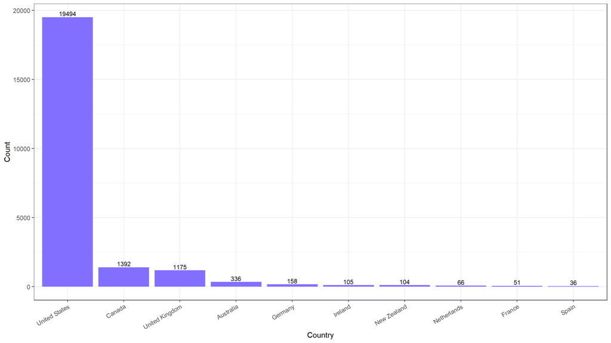

```r
#we will filter for countries with the most respondents
ask_a_manager_2021_cleaned %>%
  count(country, sort=TRUE) %>%
  top_n(10) %>%

#plot the counts of each country
  ggplot(aes(x=fct_reorder(country,n,.desc=TRUE),y= n,fill=country))+
  geom_col(fill= "slateblue1")+
  theme_bw()+
  geom_text(aes(label=n),size=3,vjust=-0.25)+
  labs(y="Count",
       x="Country")+
  guides(fill=FALSE)+
  theme(axis.text.x = element_text(angle = 30, hjust = 1, vjust = 1))+
  NULL
```

```r
# use countrycode::countryname() to clean country names
```

> As the vast majority of the respondents in this survey is from the USA, the further data analysis will only focus on the US annual salary data.

```r
#delete country and rename country value as iso3, filter USA
us_data <-
  ask_a_manager_2021_cleaned %>%
  select(-country) %>%
  filter(iso3c== "USA")

us_data <- us_data %>%
  mutate(
    log_salary = log(annual_salary)
    ) %>%
  drop_na()
```

## 0.4 Analysis on US-Salary

> In the following the exploratory data analysis is conducted on the different variables to thereafter continue with hypothesis testing and regression models.

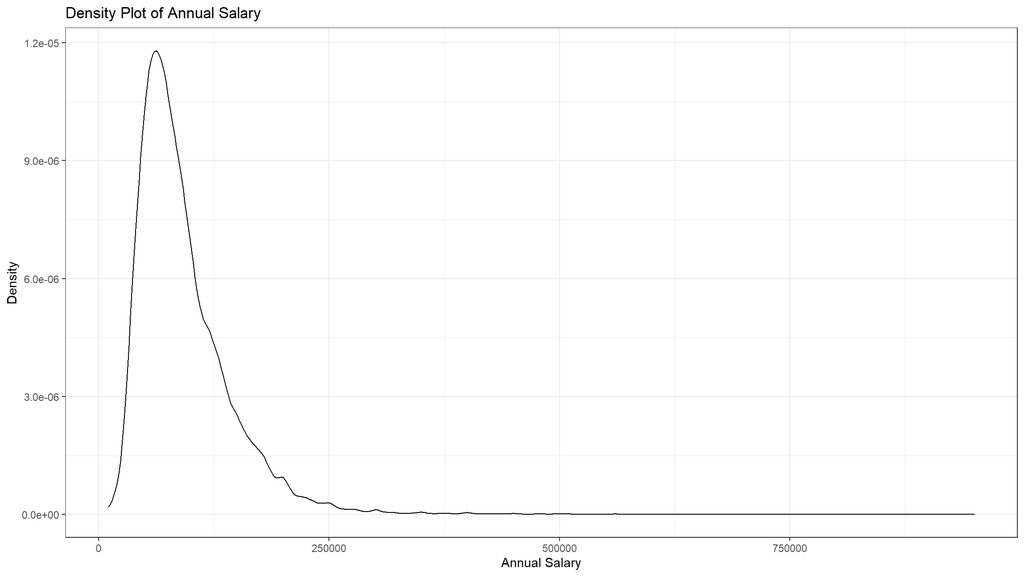

```r
# How is salary distributed?
ggplot(us_data, aes(x=annual_salary))+
  geom_density()+
 labs(x="Annual Salary",
       y="Density",
       title="Density Plot of Annual Salary")+
  theme_bw()
```

> Looking at the distribution of Annual Salary, we observe that the distribution is heavily skewed towards the right. This means that most of the respondents have an annual salary around the median, but there are some respondents who have very high annual salaries.

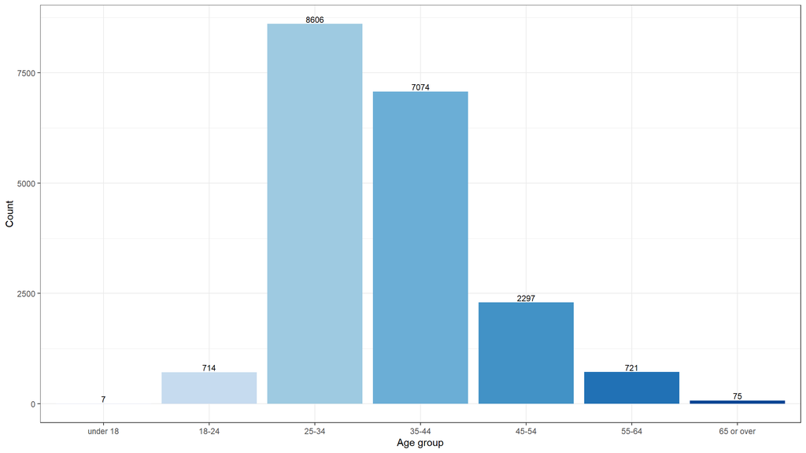

```r
# age distribution in the survey

us_data %>%
  count(age) %>%
  ggplot(aes(x=age,y=n,fill=age)) +
  geom_col()+
  labs(x="Age group",
       y="Count")+
  geom_text(aes(label=n),size=3,vjust=-0.25)+
  theme_bw()+
  scale_fill_brewer(palette = "Blues")+
  guides(fill=FALSE)
```

> Vast majority of survey respondents are between 25-44.

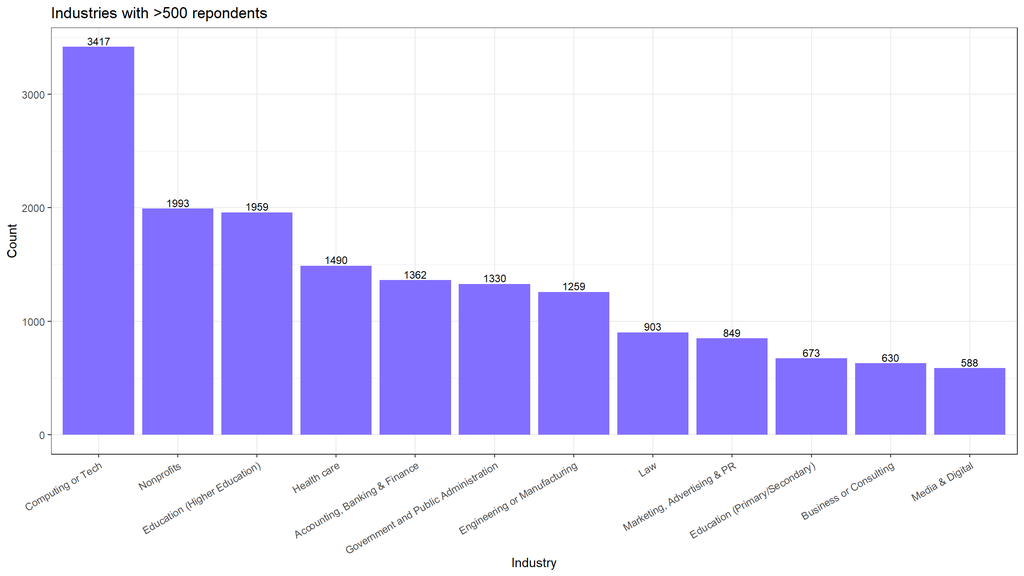

```r
# More than 1000 industries can be observed in our dataframe
#we will filter for industries with more than 500 respondents

us_data %>%
  count(industry, sort=TRUE) %>%
  mutate(percent = 100* n/sum(n)) %>%
  filter(n>=500) %>%
  ggplot(aes(x=fct_reorder(industry,n,.desc = TRUE),y= n,fill=industry))+
  geom_col(fill= "slateblue1")+
  geom_text(aes(label=n),size=3,vjust=-0.25)+
    labs(x="Industry",
       y="Count",
       title="Industries with >500 repondents")+
  theme_bw()+
  theme(axis.text.x = element_text(angle = 30, hjust = 1, vjust = 1))+
  guides(fill=FALSE)
```

> Higher propotion of respondents work in Computing or Tech industry. Interestingly, Nonprofits are the second most frequent industry of the survey.

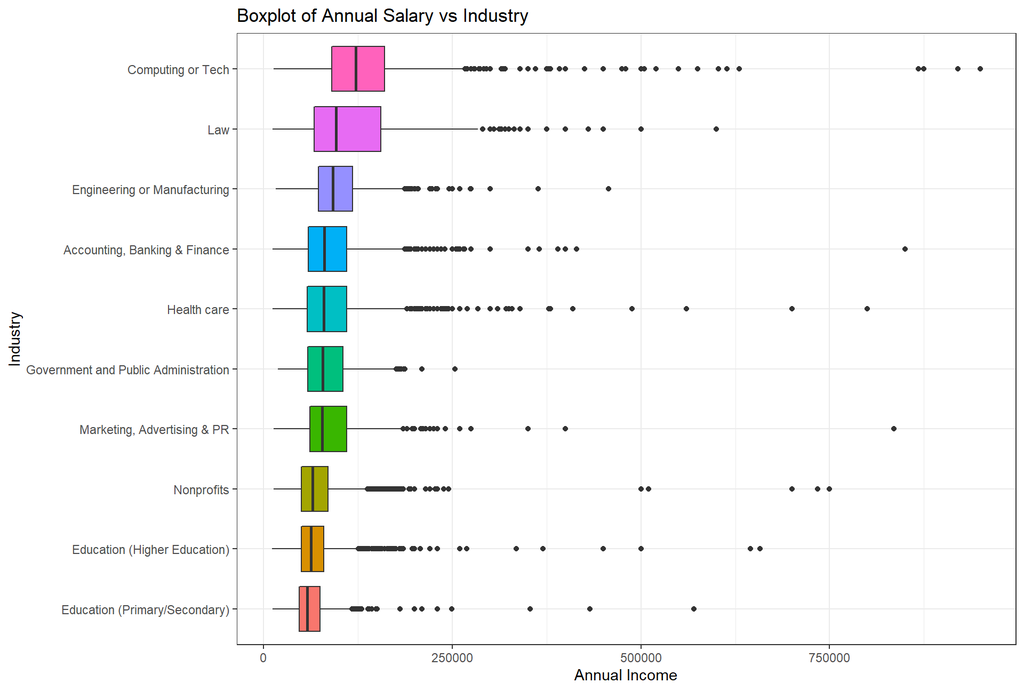

```r
top_industries <- us_data %>%
  group_by(industry) %>%
  count(sort = TRUE) %>%
  head(10) %>%
  select(industry) %>%
  pull()

us_data %>%
  filter(industry %in% top_industries) %>%
  mutate(industry = fct_reorder(industry, annual_salary)) %>%
  ggplot(aes(x = annual_salary, y = industry,
             fill = industry)) +
  geom_boxplot() +
  #add labels
  labs(title = 'Boxplot of Annual Salary vs Industry',
        x = 'Annual Income',
        y = 'Industry') +
  theme_bw()+
  guides(fill= FALSE)
```

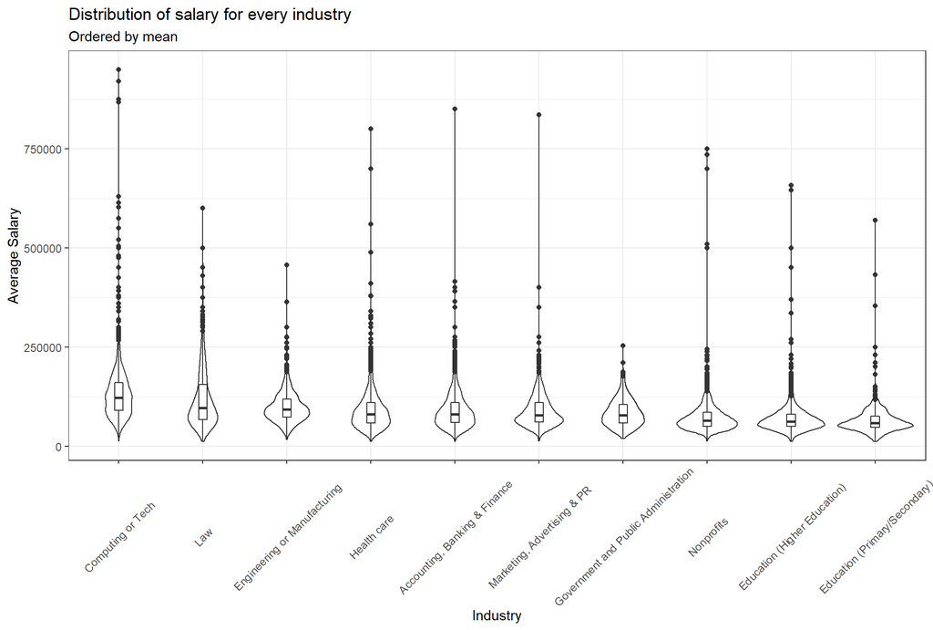

```r
us_data %>%
  filter(industry %in% top_industries) %>%
  group_by(industry) %>%
  ggplot(aes(x = reorder(industry, -annual_salary), y = annual_salary)) +
  geom_violin() +
  geom_boxplot(width=0.1)+
  labs(x="Industry",
       y="Average Salary",
       title="Distribution of salary for every industry",
       subtitle="Ordered by mean")+
  theme_bw()+
  theme(axis.text.x = element_text(angle = 45, vjust = 0.5))+
  NULL
```

> As the boxplot shows, tech, law and engineering are the top three industries that have highest annual salary.

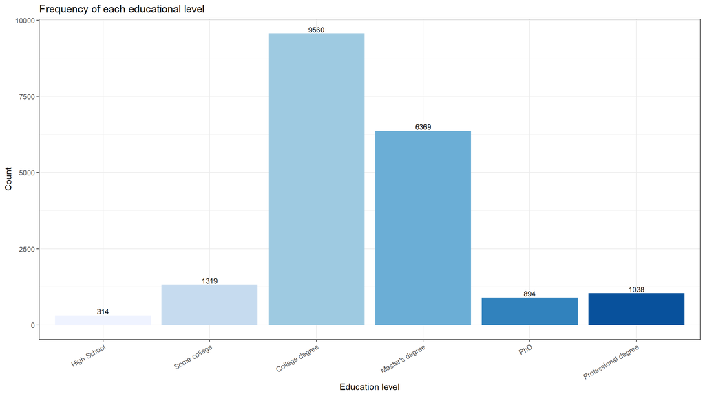

```r
# education
us_data %>%
  filter(!is.na(education_level)) %>%
  count(education_level) %>%
  ggplot(aes(x=education_level,y= n,fill=education_level))+
  geom_col()+
  theme_bw()+
  labs(title= "Frequency of each educational level",
       x= "Education level",
       y="Count")+
  scale_fill_brewer(palette = "Blues")+
  geom_text(aes(label=n),size=3,vjust=-0.25)+
  guides(fill=FALSE)+
  theme(axis.text.x = element_text(angle = 30, hjust = 1, vjust = 1))
```

> The survey respondents also display a very high education level in general.

```r
#Cleaning the race variable(white was included with other races)
us_data <- us_data %>%
  mutate(
    race_cleaned = case_when(
      race %in% c('Asian or Asian American', 'Asian or Asian American, White') ~ 'Asian or Asian American',
      race %in% c('Black or African American', 'Black or African American, White') ~ 'Black or African American',
      race %in% c('Hispanic, Latino, or Spanish origin', 'Hispanic, Latino, or Spanish origin, White') ~ 'Hispanic, Latino, or Spanish origin',
      race == "Another option not listed here or prefer not to answer" ~ "Others/Prefer not to say",
      TRUE ~ race
    )
  )
skim(us_data$race_cleaned)
```

Data summary

| Name | us_data$race_cleaned |
| --- | --- |
| Number of rows | 19494 |
| Number of columns | 1 |
| _______________________ |  |
| Column type frequency: |  |
| character | 1 |
| ________________________ |  |
| Group variables | None |

**Variable type: character**

| skim_variable | n_missing | complete_rate | min | max | empty | n_unique | whitespace |
| --- | --- | --- | --- | --- | --- | --- | --- |
| data | 0 | 1 | 5 | 35 | 0 | 5 | 0 |

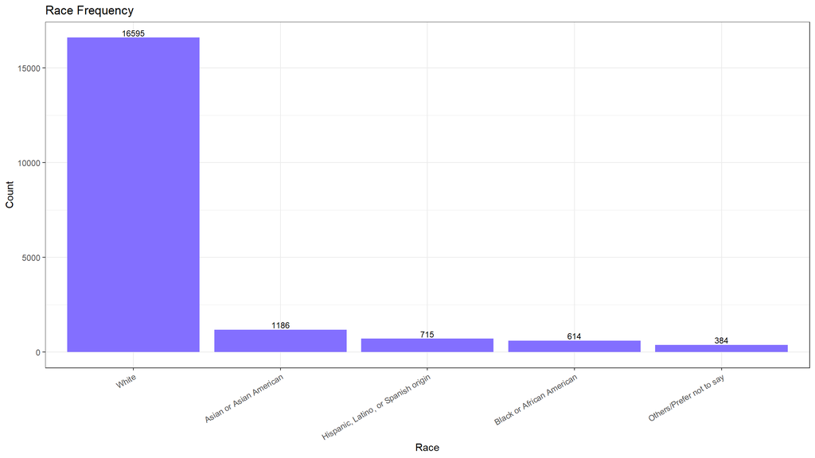

```r
# race
us_data %>%
  filter(!is.na(race_cleaned)) %>%
  count(race_cleaned) %>%
  ggplot(aes(x=fct_reorder(race_cleaned,n,.desc=TRUE),y= n,fill=race_cleaned))+
  geom_col(fill= "slateblue1")+
  theme_bw()+
  labs(title="Race Frequency",
       x= "Race",
       y="Count")+
  geom_text(aes(label=n),size=3,vjust=-0.25)+
  guides(fill=FALSE)+
  theme(axis.text.x = element_text(angle = 30, hjust = 1, vjust = 1))
```

> The vast majority of the respondents are white people.

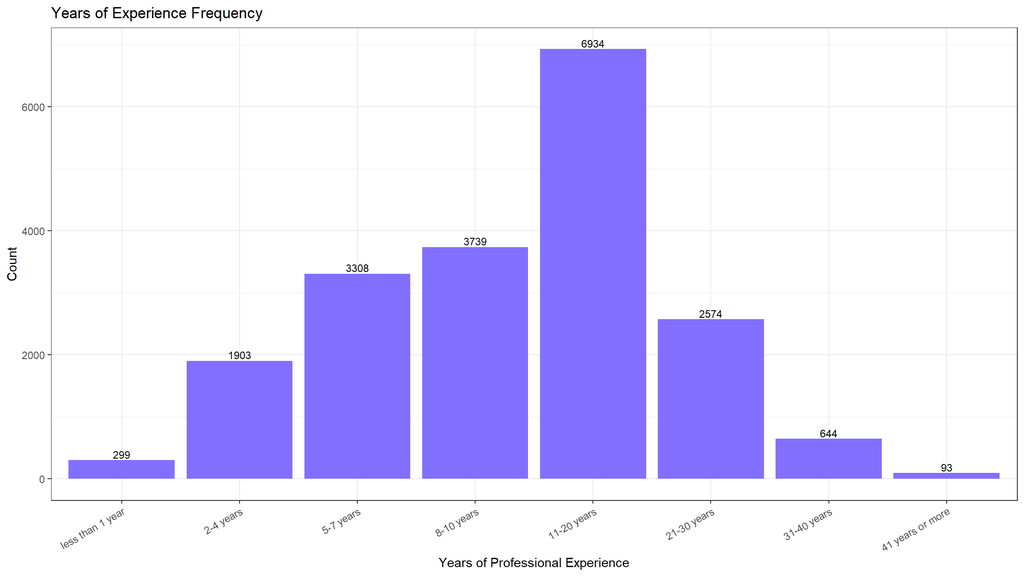

```r
# overall_years_of_professional_experience
us_data %>%
  count(overall_experience ) %>%
  ggplot(aes(x=overall_experience,y = n))+
  geom_col(fill= "slateblue1")+
  labs(x="Years of Professional Experience",
       y="Count",
       title="Years of Experience Frequency")+
  theme_bw()+
  geom_text(aes(label=n),size=3,vjust=-0.25)+
  theme(axis.text.x = element_text(angle = 30, hjust = 1, vjust = 1))
```

> The largest propotion of respondents have 11-20 years of professional experience.

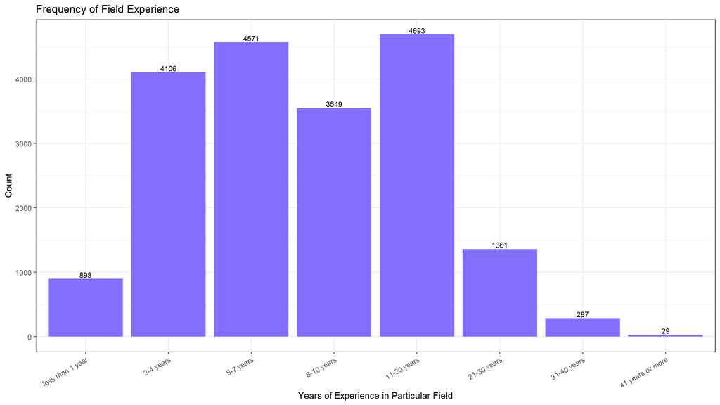

```r
# years_of_experience_in_field
us_data %>%
  count(field_experience) %>%
  ggplot(aes(x=field_experience,y = n))+
  geom_col(fill= "slateblue1")+
   labs(x="Years of Experience in Particular Field",
       y="Count",
       title="Frequency of Field Experience")+
  theme_bw()+
  geom_text(aes(label=n),size=3,vjust=-0.25)+
  theme(axis.text.x = element_text(angle = 30, hjust = 1, vjust = 1))
```

> Years of experience in particular field are more evenly distributed.

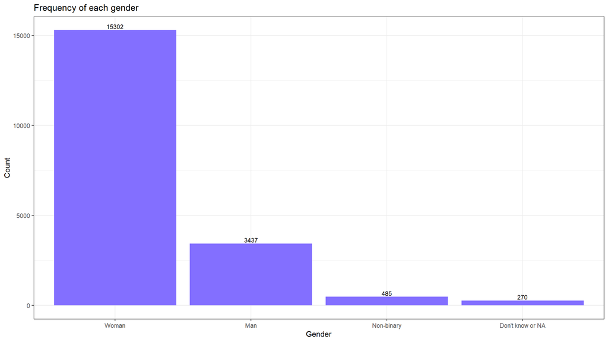

```r
# gender
us_data %>%
  count(gender) %>%
  ggplot(aes(x=fct_reorder(gender,n,.desc=TRUE),y = n,fill=gender))+
  geom_col(fill= "slateblue1")+
  theme_bw()+
  geom_text(aes(label=n),size=3,vjust=-0.25)+
  guides(fill=FALSE)+
  labs(title= "Frequency of each gender",
       x="Gender",
       y="Count")+
  NULL
```

> Survey respondents of America are mostly female.

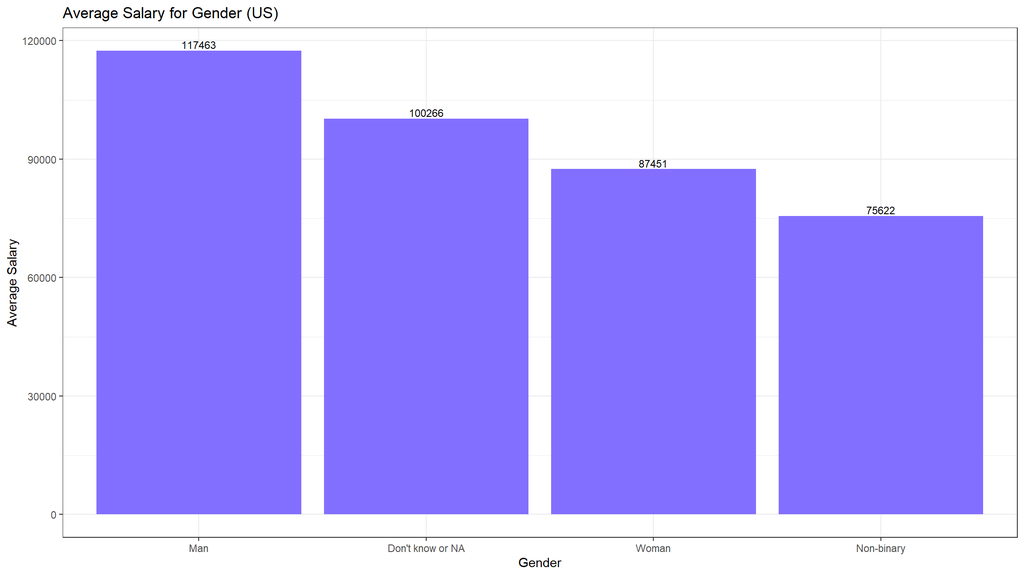

```r
#create table
us_data %>%
  group_by(gender) %>%
  summarize(
    mean_salary = mean(annual_salary)
  ) %>%
#plot barchart
  ggplot(aes(x = reorder(gender, -mean_salary), y = mean_salary)) +
  geom_col(fill= "slateblue1")+
 geom_text(aes(label=round(mean_salary,0)),size=3,vjust=-0.25)+
   labs(x="Gender",
       y="Average Salary",
       title="Average Salary for Gender (US)")+
  theme_bw()
```

> Average salary of men is higher than woman and non-binary respondents.

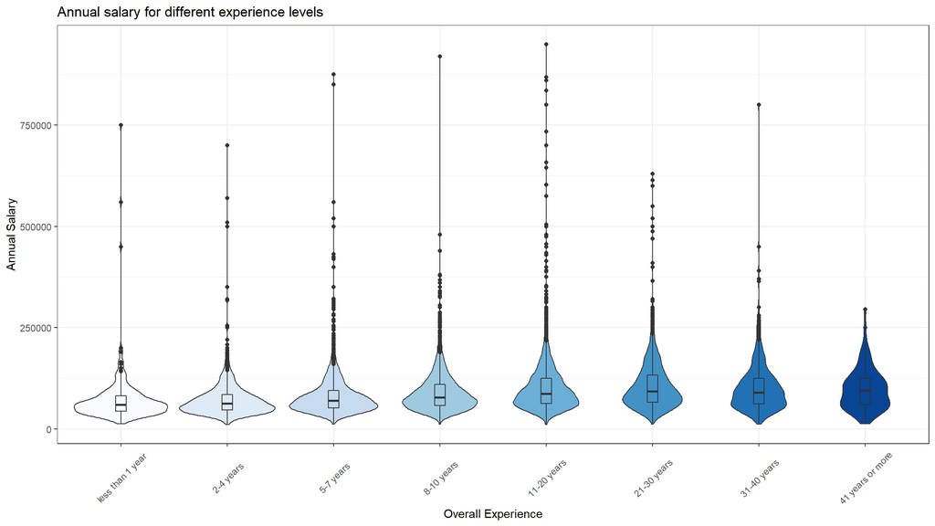

```r
us_data %>%
  ggplot(aes(x = overall_experience, y = annual_salary, fill=overall_experience)) +
  geom_violin()+
  geom_boxplot(width=0.1)+
  scale_fill_brewer(palette="Blues") + theme_classic()+
   labs(x="Overall Experience",
       y="Annual Salary",
       title="Annual salary for different experience levels")+
  theme_bw()+
  theme(axis.text.x = element_text(angle = 45, vjust = 0.5))+
  guides(fill=FALSE)+
  NULL
```

> On average, as overall experience increases, the median salary increases, and the variability increases but decreases towards the end.

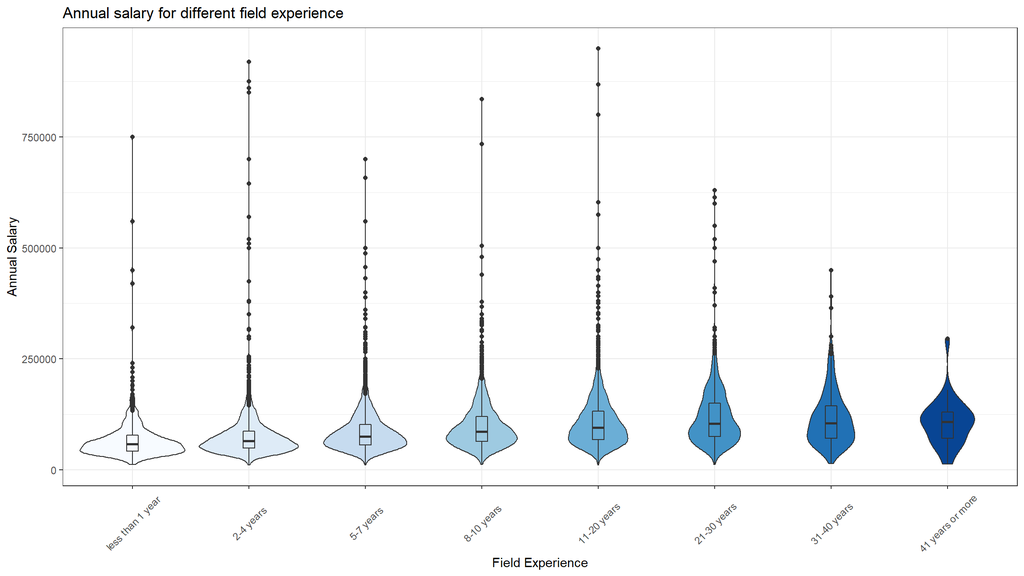

```r
us_data %>%

  ggplot(aes(x = field_experience, y = annual_salary, fill=field_experience)) +
  geom_violin()+
  geom_boxplot(width=0.1)+
  scale_fill_brewer(palette="Blues") + theme_classic()+
  labs(x="Field Experience",
       y="Annual Salary",
       title="Annual salary for different field experience")+
  theme_bw()+
  theme(axis.text.x = element_text(angle = 45, vjust = 0.5))+
  guides(fill=FALSE)+


  NULL
```

> On average, as field experience increases, the median salary increases, and the variability increases but decreases towards the end.

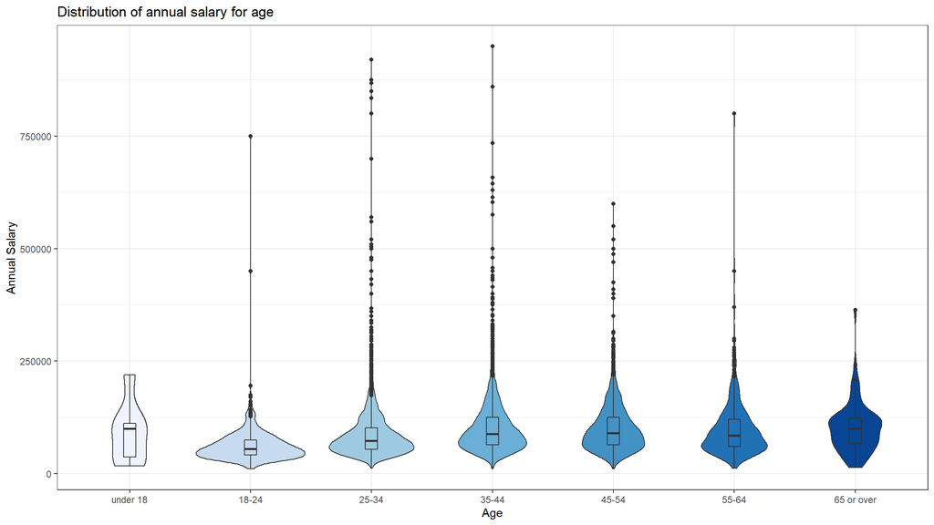

```r
us_data %>%
  group_by(age) %>%

  ggplot(aes(x = age, y = annual_salary, fill=age)) +
  geom_violin()+
  scale_fill_brewer(palette="Blues") + theme_classic()+
  geom_boxplot(width=0.1)+
   labs(x="Age",
       y="Annual Salary",
       title="Distribution of annual salary for age")+
  theme_bw()+
  guides(fill=FALSE)+
  NULL
```

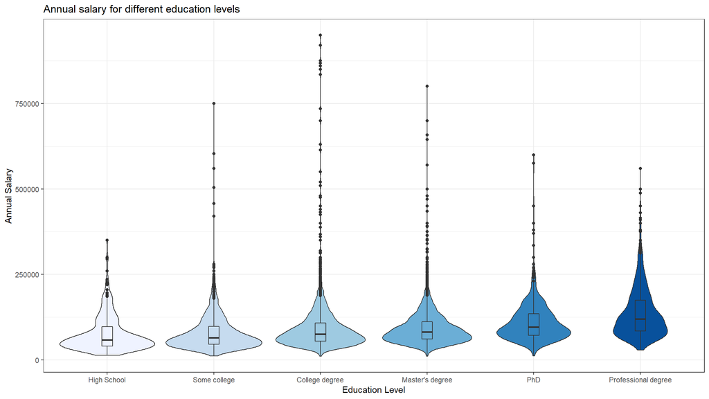

```r
us_data %>%
  ggplot(aes(x = education_level, y = annual_salary,fill=education_level)) +
  geom_violin() +
  scale_fill_brewer(palette="Blues") + theme_classic()+
  geom_boxplot(width=0.1)+
  labs(x="Education Level",
       y="Annual Salary",
       title="Annual salary for different education levels")+
  theme_bw()+
  guides(fill=FALSE)+
  NULL
```

> On average, more educated people have a higher median salary, although this difference is low for High School and Some college.

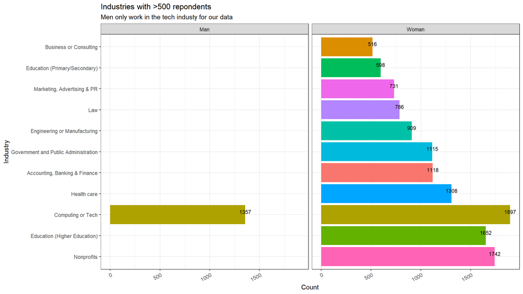

```r
us_data %>%
  group_by(gender) %>%
  count(industry, sort=TRUE) %>%
  mutate(percent = 100* n/sum(n)) %>%
  filter(n>=500) %>%
  ggplot(aes(y=fct_reorder(industry,n,.desc = TRUE),x= n,fill=industry))+
  geom_col()+
  geom_text(aes(label=n),size=3,vjust=-0.25)+
  facet_wrap(~gender)+
    labs(x="Count",
         y="Industry",
         title="Industries with >500 repondents",
         subtitle="Men only work in the tech industy for our data")+
  theme_bw()+
  theme(axis.text.x = element_text(angle = 30, hjust = 1, vjust = 1))+
  guides(fill=FALSE)
```

> To investigate gender gaps in salary for various industries, we plot a graph which shows the difference between mean salaries for males and females for top industries -

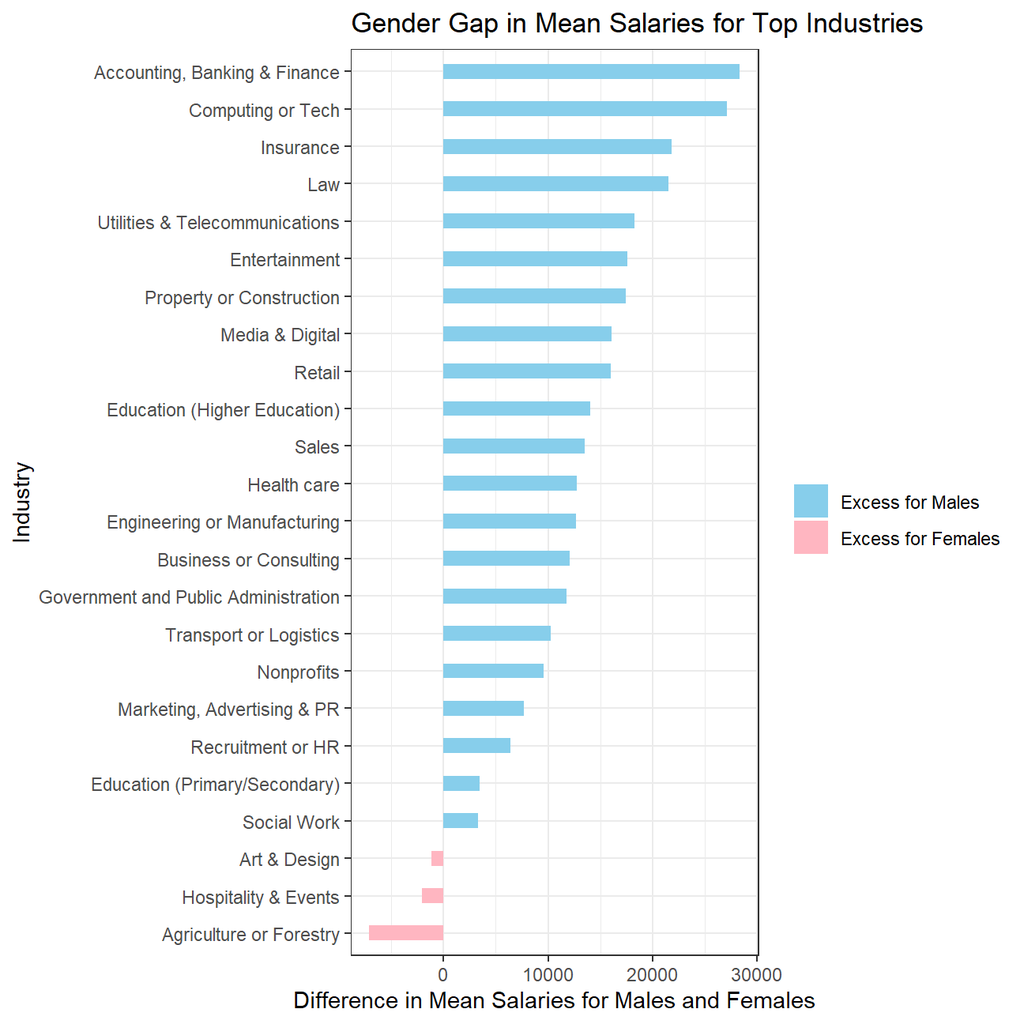

```r
gender <- us_data %>%

  #Filtering data for top industries (having at least 500 respondents) and Men and Women
  filter(industry %in% industry_list, gender %in% c("Man", "Woman")) %>%
  group_by(industry, gender) %>%

  #Calculating mean salaries after grouping
  summarize(
    mean_salary = mean(annual_salary)
  )

#Pivoting the data to wide format
gender_pivot <-
  pivot_wider(
    gender,
    names_from = gender,
    values_from = mean_salary
  )

#Calculating the difference between average salaries of males and females
gender_pivot <- gender_pivot %>%
  mutate(
    diff = Man - Woman,
    indicator = ifelse(diff > 0, "Excess for Males", "Excess for Females")
  )

#Plotting the data
ggplot(gender_pivot, aes(x=reorder(industry, diff), y=diff, label=diff)) +
  geom_bar(stat = 'identity', width = 0.4, aes(fill = indicator)) +

  #Filling the bars according to excess means
  scale_fill_manual(labels = c("Excess for Males", "Excess for Females"),
                    values = c("Excess for Males" = "Sky Blue", "Excess for Females" = "Light Pink")) +
  #Adding title and axes labels
  labs(
    title = "Gender Gap in Mean Salaries for Top Industries",
    y = "Difference in Mean Salaries for Males and Females",
    x = "Industry"
  ) +
  theme_bw() +
  #Removing the legend title
  guides(fill=guide_legend(title="")) +
  coord_flip()
```

> We observe that for most of the top industries, males have a higher average salary than females. The difference is largest for Accounting, Banking & Finance, and Computing & Tech industries. For only 3 industries - Agriculture or Forestry, Hospitality & Events and Art& Design, the average salary of females is higher.

> Now, we explore gender gap in salary for states

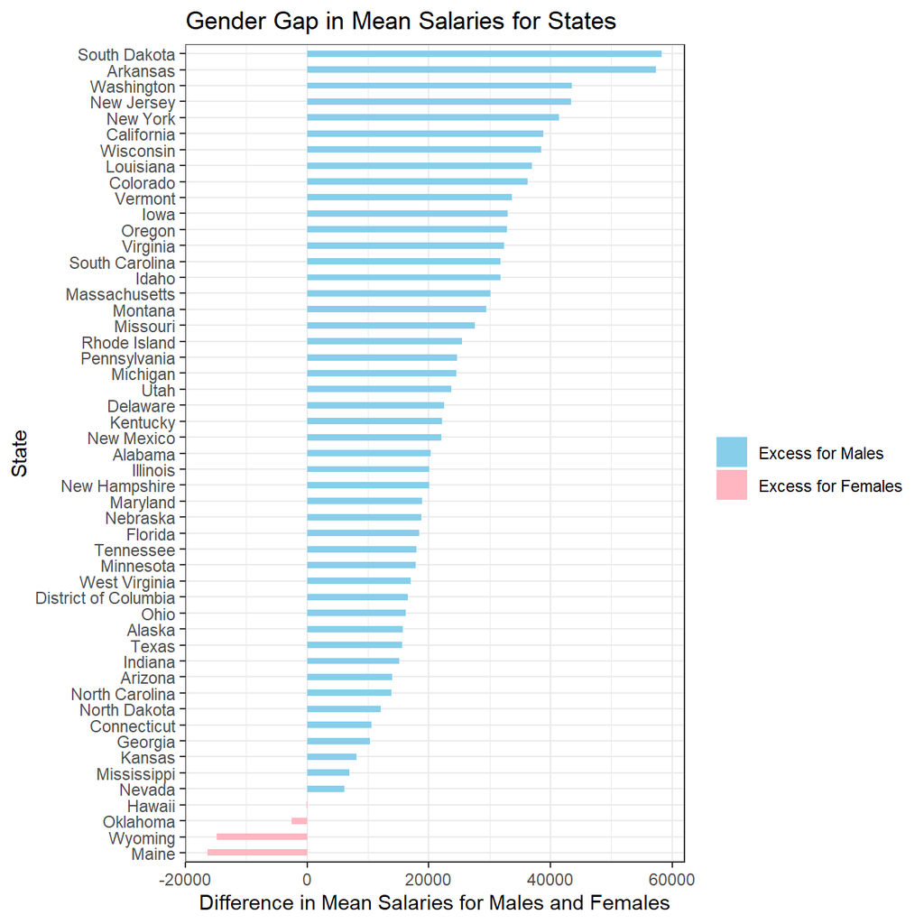

```r
states_pay <- us_data %>%

  #Filtering data for Men and Women and removing NAs for states
  filter(state != "NA", gender %in% c("Man", "Woman")) %>%
  group_by(state, gender) %>%

  #Calculating mean salaries after grouping
  summarize(
    mean_salary = mean(annual_salary)
  )

#Pivoting the data to wide format
states_pivot <-
  pivot_wider(
    states_pay,
    names_from = gender,
    values_from = mean_salary
  )

#Calculating the difference between average salaries of males and females
states_pivot <- states_pivot %>%
  mutate(
    diff = Man - Woman,
    indicator = ifelse(diff > 0, "Excess for Males", "Excess for Females")
  )

#Plotting the data
ggplot(states_pivot, aes(x=reorder(state, diff), y=diff, label=diff)) +
  geom_bar(stat = 'identity', width = 0.4, aes(fill = indicator)) +

  #Filling the bars according to excess means
  scale_fill_manual(labels = c("Excess for Males", "Excess for Females"),
                    values = c("Excess for Males" = "Sky Blue", "Excess for Females" = "Light Pink")) +
  #Adding title and axes labels
  labs(
    title = "Gender Gap in Mean Salaries for States",
    y = "Difference in Mean Salaries for Males and Females",
    x = "State"
  ) +
  theme_bw() +
  #Removing the legend title
  guides(fill=guide_legend(title="")) +
  coord_flip()
```

> We observe that most of the states have a higher average salary for males, as compared to females. The difference is the largest for South Dakota and Arkansas. For only 3 states - Oklahoma, Wyoming and Maine, the average salary of females is higher.

*Observations for Hypothesis 1 from Exploratory Data Analysis*

> - Observation 1: Mean salary men > Mean salary women

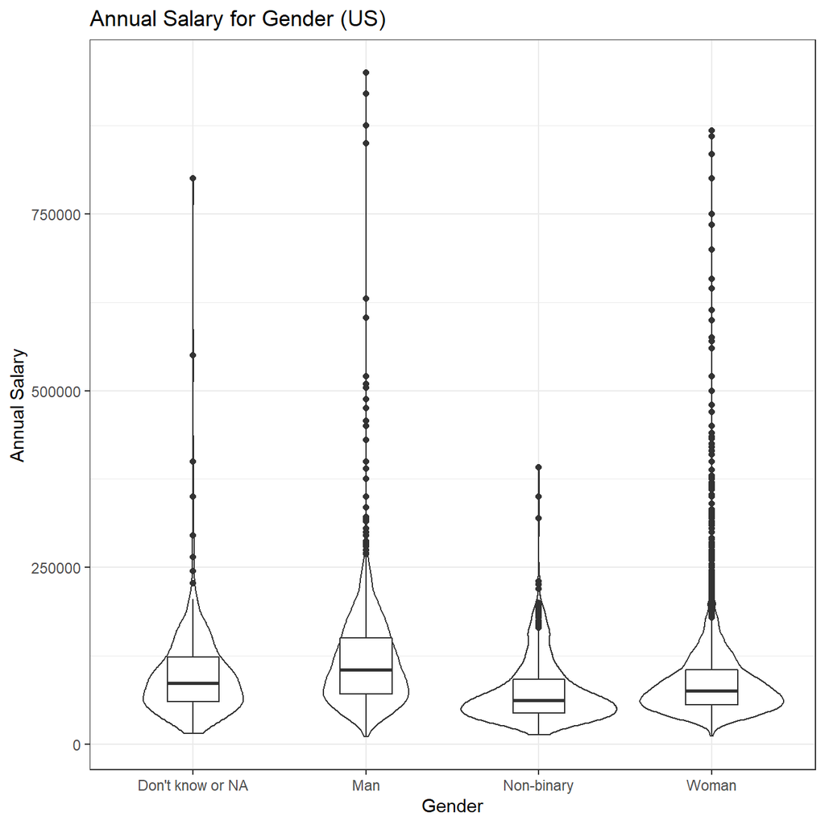

```r
#boxplots
us_data %>%
  group_by(gender) %>%
  ggplot(aes(x=gender, y=annual_salary))+
  geom_violin()+
  geom_boxplot(width=0.3)+
  labs(x="Gender",
       y="Annual Salary",
       title="Annual Salary for Gender (US)")+
  theme_bw()
```

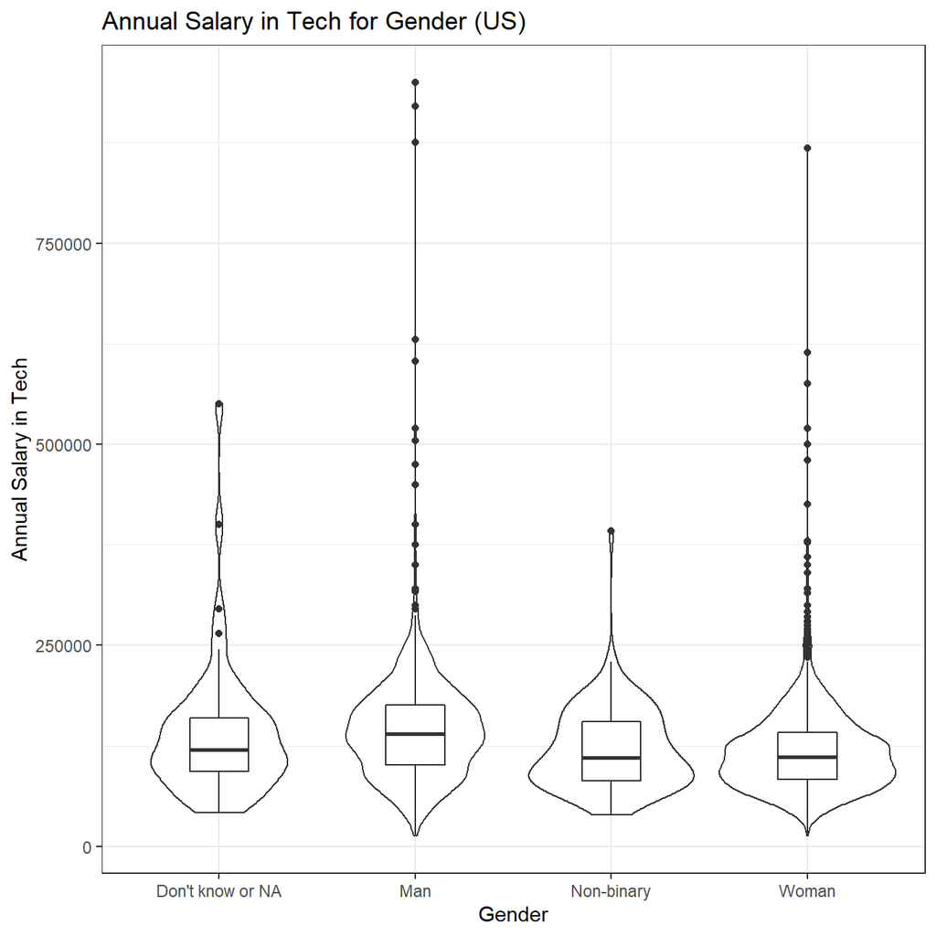

```r
us_data %>%
  filter(industry == "Computing or Tech") %>%
  group_by(gender) %>%
  ggplot(aes(x=gender, y=annual_salary))+
  geom_violin()+
  geom_boxplot(width=0.3)+
   labs(x="Gender",
       y="Annual Salary in Tech",
       title="Annual Salary in Tech for Gender (US)")+
  theme_bw()
```

> Following these observations we compare whether the average annual salary for tech industry is different between men and woman.

### 0.4.1 Hypothesis 1:

Null Hypothesis $H_0$ : $\mu_{Men.tech.salary} - \mu_{Female.tech.salary} = 0$

Alternative Hypothesis $H_1$ : $\mu_{Men.tech.salary} - \mu_{Female.tech.salary}\neq 0$

```r
#compute confidence intervals

us_data_menvswomen <- us_data%>%
  filter(industry == "Computing or Tech") %>%
  filter(gender %in% c("Man", "Woman")) %>%
  group_by(gender) %>%
  summarise(mean_salary = mean(annual_salary),
            median_salary = median(annual_salary),
            sd_salary = sd(annual_salary),
            count = n(),
            # get t-critical value with (n-1) degrees of freedom
            t_critical = qt(0.975, count-1),
            se_salary = sd_salary/sqrt(count),
            margin_of_error = t_critical * se_salary,
            salary_low = mean_salary - margin_of_error,
            salary_high = mean_salary + margin_of_error) %>%
  arrange(desc(mean_salary))

print(us_data_menvswomen, width = Inf)
```

```
## # A tibble: 2 x 10
##   gender mean_salary median_salary sd_salary count t_critical se_salary
##   <chr>        <dbl>         <dbl>     <dbl> <int>      <dbl>     <dbl>
## 1 Man        146124.        140000    70964.  1357       1.96     1926.
## 2 Woman      119010.        110900    55338.  1897       1.96     1271.
##   margin_of_error salary_low salary_high
##             <dbl>      <dbl>       <dbl>
## 1           3779.    142345.     149903.
## 2           2492.    116518.     121502.
```

```r
 # using welch  t test
us_data_2 <- us_data %>%
    filter(industry == "Computing or Tech") %>%
  filter(gender %in% c("Man", "Woman"))


t.test(annual_salary ~ gender , data = us_data_2)
```

```
##
##  Welch Two Sample t-test
##
## data:  annual_salary by gender
## t = 12, df = 2459, p-value <2e-16
## alternative hypothesis: true difference in means between group Man and group Woman is not equal to 0
## 95 percent confidence interval:
##  22589 31639
## sample estimates:
##   mean in group Man mean in group Woman
##              146124              119010
```

> We use confidence interval and t-test to show the difference. The confidence interval of men is [142345,149903] which is not overlapping with women [116518,121502] and p-value in the t-test is <2e-16. Therefore, we reject the null hypothesis and conclude there is a significant difference in annual salary between men and women who work in tech industry.

*Observations for Hypothesis 2 from Exploratory Data Analysis*

```r
#create a table with mean salaries across different US cities
us_data %>%
  group_by(city) %>%
  summarise(mean_salary = mean(annual_salary),
            count = n()
         ) %>%
  arrange(desc(mean_salary)) %>%
  #display only top 15
 top_n(15)
```

```
## # A tibble: 15 x 3
##    city           mean_salary count
##    <chr>                <dbl> <int>
##  1 San Francisco      150330.   504
##  2 Seattle            120936.   625
##  3 New York           117199.   678
##  4 Washington         111221.   327
##  5 New York City      108916.   441
##  6 Los Angeles        107918.   431
##  7 Washington, DC     102140    223
##  8 Boston             101990.   714
##  9 Atlanta            100895.   297
## 10 Chicago             99808.   706
## 11 Austin              96355.   316
## 12 Denver              94888.   277
## 13 Portland            93335.   415
## 14 Philadelphia        90669.   304
## 15 Minneapolis         87579.   332
```

> San Francisco has the highest mean salary of all US cities

> So far, we have the following observation of San Francisco and tech industry. - Observation 1: San Francisco has the highest mean salary of all US cities - Observation 2: Mean salary is highest in Computing &Tech

> We want to figure out whether this is because most people in San Francisco tend to work in tech industry compared to other cities in America.

### 0.4.2 Hypothesis 2:

Null Hypothesis $H_0$ : $p_{SF.tech} = p_{notSF.tech}$

Alternative Hypothesis $H_1$ : $p_{SF.tech} \neq p_{notSF.tech}$

```r
#we will examine if San Francisco holds a bigger proportion of tech employees than other cities

#find % of tech employees in SF
us_data %>%
  filter(city == "San Francisco") %>%
  count(industry) %>%
  mutate(percent = n/sum(n)*100,
         total = sum(n)) %>%
  arrange(desc(n))
```

```
## # A tibble: 22 x 4
##    industry                                 n percent total
##    <chr>                                <int>   <dbl> <int>
##  1 Computing or Tech                      243   48.2    504
##  2 Nonprofits                              49    9.72   504
##  3 Accounting, Banking & Finance           41    8.13   504
##  4 Marketing, Advertising & PR             19    3.77   504
##  5 Law                                     17    3.37   504
##  6 Engineering or Manufacturing            16    3.17   504
##  7 Health care                             15    2.98   504
##  8 Government and Public Administration    13    2.58   504
##  9 Insurance                               11    2.18   504
## 10 Recruitment or HR                       11    2.18   504
## # ... with 12 more rows
```

```r
#find % of tech employees in US excluding SF
us_data %>%
  filter(city != "San Francisco") %>%
  count(industry) %>%
  mutate(percent = n/sum(n)*100,
         total = sum(n)) %>%
  arrange(desc(n))
```

```
## # A tibble: 24 x 4
##    industry                                 n percent total
##    <chr>                                <int>   <dbl> <int>
##  1 Computing or Tech                     3174   16.7  18990
##  2 Education (Higher Education)          1952   10.3  18990
##  3 Nonprofits                            1944   10.2  18990
##  4 Health care                           1475    7.77 18990
##  5 Accounting, Banking & Finance         1321    6.96 18990
##  6 Government and Public Administration  1317    6.94 18990
##  7 Engineering or Manufacturing          1243    6.55 18990
##  8 Law                                    886    4.67 18990
##  9 Marketing, Advertising & PR            830    4.37 18990
## 10 Education (Primary/Secondary)          665    3.50 18990
## # ... with 14 more rows
```

```r
#two proportion z test
tech<- c(243, 3174)
totals <- c(504, 18990)

res1 <- prop.test(x = tech, n = totals)
res1
```

```
##
##  2-sample test for equality of proportions with continuity correction
##
## data:  tech out of totals
## X-squared = 335, df = 1, p-value <2e-16
## alternative hypothesis: two.sided
## 95 percent confidence interval:
##  0.27 0.36
## sample estimates:
## prop 1 prop 2
##  0.482  0.167
```

> We observe that in San Francisco the proportion of tech-employees is 48% vs. 16% in other US cities. Proportion of tech-employees in San Francisco is significantly different than in other US cities as P-value < 2e-16.

*Observations for Hypothesis 3 from Exploratory Data Analysis*

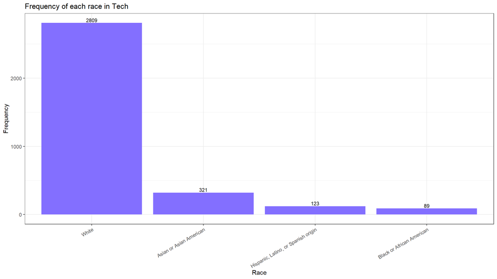

```r
#plot race in tech industry

us_data %>%
  filter(industry == "Computing or Tech", race_cleaned != "Others/Prefer not to say") %>%
  group_by(race_cleaned) %>%
  summarize(
   count = n(),
   mean_salary = mean(annual_salary)
   ) %>%
  ggplot(aes(x = reorder(race_cleaned, -count), y = count)) +
  geom_col(fill= "slateblue1") +
  theme(axis.text.x = element_text(angle = 45, vjust = 0.5))+
   labs(x="Race",
       y="Frequency",
       title="Frequency of each race in Tech")+
  theme_bw()+
  geom_text(aes(label=count),size=3,vjust=-0.25)+
  theme(axis.text.x = element_text(angle = 30, hjust = 1, vjust = 1))
```

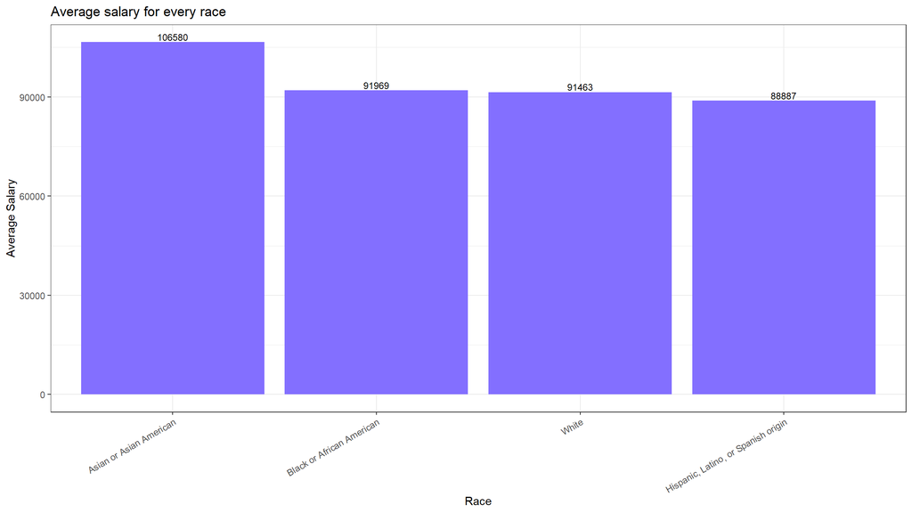

```r
us_data %>%
  group_by(race_cleaned) %>%
  filter (race_cleaned != "Others/Prefer not to say" ) %>%
  summarize(
    mean_salary = mean(annual_salary)
  ) %>%

  ggplot(aes(x = reorder(race_cleaned, -mean_salary), y = mean_salary)) +
  geom_col(fill= "slateblue1") +
  labs(x="Race",
       y="Average Salary",
       title="Average salary for every race")+
  theme_bw()+
  geom_text(aes(label=round(mean_salary,0)),size=3,vjust=-0.25)+
  theme(axis.text.x = element_text(angle = 30, hjust = 1, vjust = 1))
```

> In the previous two graphs, we see that mean salary of Asian/Asian American is higher than other races. We want to know if this result is significant.

### 0.4.3 Hypothesis 3:

Null Hypothesis $H_0$ : $p_{Asian.Salary} = p_{White.Salary}$

Alternative Hypothesis $H_1$ : $p_{Asian.Salary} \neq p_{White.Salary}$

```r
us_data%>%
  group_by(race_cleaned) %>%
  filter (race_cleaned != "Others/Prefer not to say" ) %>%
  summarise(mean_salary = mean(annual_salary),
            median_salary = median(annual_salary),
            sd_salary = sd(annual_salary),
            count = n(),
            # get t-critical value with (n-1) degrees of freedom
            t_critical = qt(0.975, count-1),
            se_salary = sd_salary/sqrt(count),
            margin_of_error = t_critical * se_salary,
            salary_low_CI = mean_salary - margin_of_error,
            salary_high_CI = mean_salary + margin_of_error) %>%
  arrange(desc(mean_salary))
```

```
## # A tibble: 4 x 10
##   race_cleaned    mean_salary median_salary sd_salary count t_critical se_salary
##   <chr>                 <dbl>         <dbl>     <dbl> <int>      <dbl>     <dbl>
## 1 Asian or Asian~     106580.        96142.    53587.  1186       1.96     1556.
## 2 Black or Afric~      91969.        80000     56708.   614       1.96     2289.
## 3 White                91463.        79000     53972. 16595       1.96      419.
## 4 Hispanic, Lati~      88887.        75400     59019.   715       1.96     2207.
## # ... with 3 more variables: margin_of_error <dbl>, salary_low_CI <dbl>,
## #   salary_high_CI <dbl>
```

```r
 # using welch  t test
us_data_race <- us_data %>%
  filter(race_cleaned %in% c("White", "Asian or Asian American"))

t.test(annual_salary ~ race_cleaned , data = us_data_race)
```

```
##
##  Welch Two Sample t-test
##
## data:  annual_salary by race_cleaned
## t = 9, df = 1363, p-value <2e-16
## alternative hypothesis: true difference in means between group Asian or Asian American and group White is not equal to 0
## 95 percent confidence interval:
##  11956 18278
## sample estimates:
## mean in group Asian or Asian American                   mean in group White
##                                106580                                 91463
```

> By comparing the confidence interval of annual income between each race, we see there is no overlap between Asian and other races. And the t-test between Asian and White has a p-value <2e-16. Therefore, we conclude annual salary of Asian is significantly higher than other races.

*Observations for Hypothesis 4 from Exploratory Data Analysis*

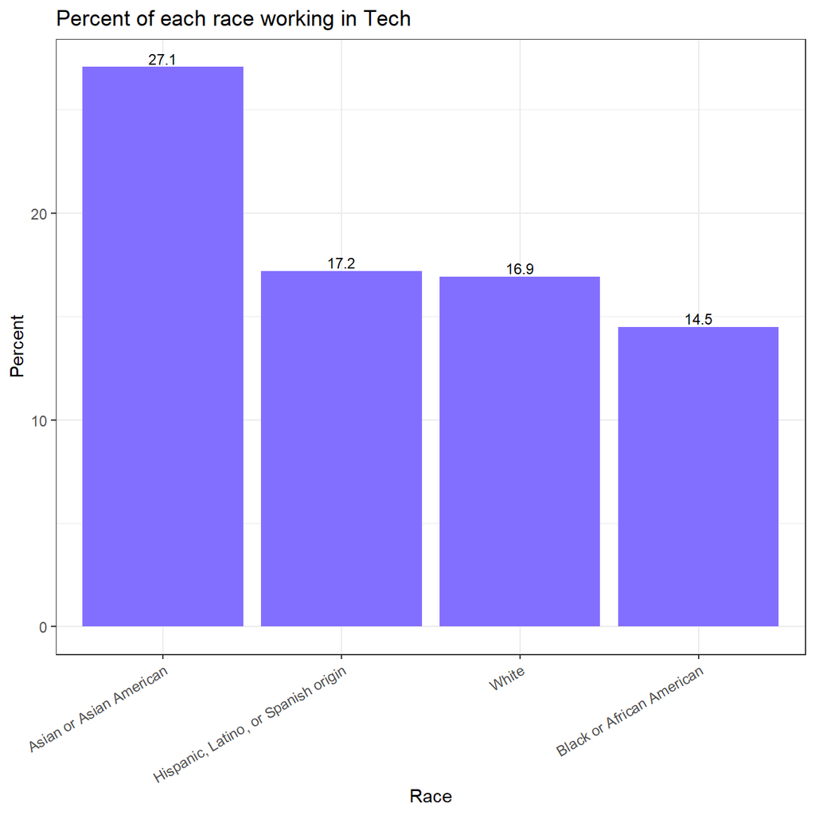

```r
us_data %>%
  group_by(race_cleaned) %>%
  filter(race_cleaned != "Others/Prefer not to say") %>%
  mutate(
    is_tech = case_when(
      industry == "Computing or Tech" ~ 1,
      TRUE ~ 0
    )
  ) %>%
  summarize(
    percent_tech = mean(is_tech) * 100
  ) %>%
  arrange(desc(percent_tech)) %>%
  ggplot(aes(x = reorder(race_cleaned,-percent_tech), y = percent_tech)) +
  geom_col(fill= "slateblue1") +
  theme(axis.text.x = element_text(angle = 45, vjust = 0.5))+
   labs(x="Race",
       y="Percent",
       title="Percent of each race working in Tech")+
  theme_bw()+
  geom_text(aes(label=round(percent_tech,1)),size=3,vjust=-0.25)+
  theme(axis.text.x = element_text(angle = 30, hjust = 1, vjust = 1))
```

```r
us_data %>%
  group_by(city) %>%
  filter(city %in% c("San Francisco", "Seattle","New York","Washington")) %>%
  mutate(
    is_asian_american = case_when(
      race == "Asian or Asian American" ~ 1,
      TRUE ~ 0
    )
  ) %>%
  summarize(
    proportion_of_asian_americans = mean(is_asian_american) * 100
  ) %>%
  arrange(desc(proportion_of_asian_americans))
```

```
## # A tibble: 4 x 2
##   city          proportion_of_asian_americans
##   <chr>                                 <dbl>
## 1 San Francisco                         18.1
## 2 New York                              10.6
## 3 Seattle                                6.08
## 4 Washington                             2.75
```

> Therefore, we want to figure out whether Asian tend to work in tech industries than other fields which leads the result of a large percentage in San Francisco.

### 0.4.4 Hypothesis 4:

Null Hypothesis $H_0$ : $p_{Asian.tech} = p_{other.tech}$

Alternative Hypothesis $H_1$ : $p_{Asian.tech} \neq p_{other.tech}$

```r
#calculate proportions

us_data%>%
  mutate(tech_or_not = case_when(industry == "Computing or Tech"& race_cleaned=="Asian or Asian American" ~ "asian in tech",
                                 industry != "Computing or Tech"& race_cleaned=="Asian or Asian American" ~ "asian in other industry",
                                 industry == "Computing or Tech"& race_cleaned!="Asian or Asian American" ~ "other in tech",
                                 industry != "Computing or Tech"& race_cleaned!="Asian or Asian American" ~ "other in other industry")
  ) %>%
  count(tech_or_not)
```

```
## # A tibble: 4 x 2
##   tech_or_not                 n
##   <chr>                   <int>
## 1 asian in other industry   865
## 2 asian in tech             321
## 3 other in other industry 15212
## 4 other in tech            3096
```

```r
#two proportion z test
asians<- c(321, 865)
totals <- c(321+3096, 865 + 15212)

res <- prop.test(x = asians, n = totals)
res
```

```
##
##  2-sample test for equality of proportions with continuity correction
##
## data:  asians out of totals
## X-squared = 79, df = 1, p-value <2e-16
## alternative hypothesis: two.sided
## 95 percent confidence interval:
##  0.0296 0.0507
## sample estimates:
## prop 1 prop 2
## 0.0939 0.0538
```

> The porption of Asian in Tech (9.39%) is significantly different from Asian in other industries (5.38%) as P-value < 2e-16. We can conclude Asians tend to work in tech industries.

## 0.5 Regression Modeling

> We train a regression model to predict annual salary for respondents in US only. We take a look at the annual salary and the log of annual salary to decide our dependent variable (Y) -

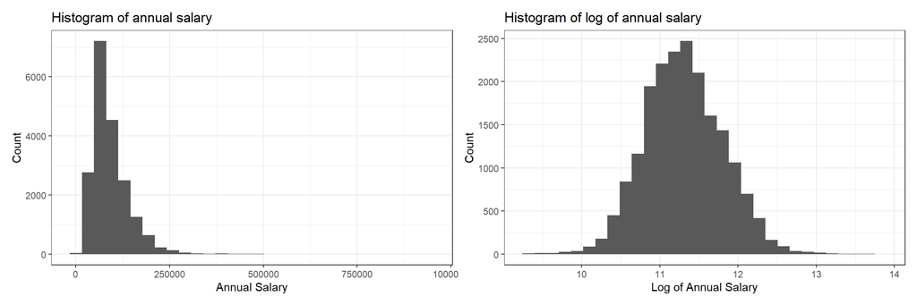

```r
library(patchwork) #Package to display plots side-by-side

#Histogram for annual salary
annual_salary_plot <- us_data %>%
  ggplot(aes(x = annual_salary)) +
  geom_histogram() +
  theme_bw() +
  labs(
    title = "Histogram of annual salary",
    y = "Count",
    x = "Annual Salary"
  )

#Histogram for log of annual salary
log_salary_plot <- us_data %>%
  ggplot(aes(x = log_salary)) +
  geom_histogram() +
  theme_bw() +
  labs(
    title = "Histogram of log of annual salary",
    y = "Count",
    x = "Log of Annual Salary"
  )

#Displaying the plots together
annual_salary_plot + log_salary_plot
```

> We observe that log of annual salary resembles the normal distribution more closely than annual salary and has lesser outliers. Hence, we proceed with the log of annual salary as the dependent variable.

```r
#Quick look at the data
glimpse(us_data)
```

```
## Rows: 19,494
## Columns: 15
## $ age                <ord> 25-34, 25-34, 25-34, 25-34, 25-34, 25-34, 45-54, 35~
## $ industry           <chr> "Education (Higher Education)", "Accounting, Bankin~
## $ job_title          <chr> "Research and Instruction Librarian", "Marketing Sp~
## $ annual_salary      <dbl> 55000, 34000, 62000, 60000, 62000, 50000, 112000, 4~
## $ currency           <chr> "USD", "USD", "USD", "USD", "USD", "USD", "USD", "U~
## $ state              <chr> "Massachusetts", "Tennessee", "Wisconsin", "South C~
## $ city               <chr> "Boston", "Chattanooga", "Milwaukee", "Greenville",~
## $ overall_experience <ord> 5-7 years, 2-4 years, 8-10 years, 8-10 years, 8-10 ~
## $ field_experience   <ord> 5-7 years, 2-4 years, 5-7 years, 5-7 years, 2-4 yea~
## $ education_level    <ord> Master's degree, College degree, College degree, Co~
## $ gender             <chr> "Woman", "Woman", "Woman", "Woman", "Man", "Man", "~
## $ race               <chr> "White", "White", "White", "White", "White", "White~
## $ iso3c              <chr> "USA", "USA", "USA", "USA", "USA", "USA", "USA", "U~
## $ log_salary         <dbl> 10.9, 10.4, 11.0, 11.0, 11.0, 10.8, 11.6, 10.7, 10.~
## $ race_cleaned       <chr> "White", "White", "White", "White", "White", "White~
```

> Taking a look at the explanatory variables for the model, we believe that age, overall_experience and field_experience would be highly correlated. Hence, we run 3 very simple models with each of these as explanatory variables to analyze which of these does the best job of explaining the variability in log of annual salary.

> Here are the 3 models to compare age, overall_experience and field_experience -

```r
#Linear regression model
model_age <- lm(log_salary ~ age, data = us_data)

#Summary of the model
mosaic::msummary(model_age)
```

```
##             Estimate Std. Error t value Pr(>|t|)
## (Intercept)  11.2566     0.0280  401.64  < 2e-16 ***
## age.L         0.3408     0.1105    3.08    0.002 **
## age.Q        -0.1134     0.1060   -1.07    0.284
## age.C        -0.1361     0.0801   -1.70    0.089 .
## age^4         0.2088     0.0492    4.24  2.2e-05 ***
## age^5        -0.0572     0.0248   -2.31    0.021 *
## age^6         0.0158     0.0107    1.48    0.138
##
## Residual standard error: 0.491 on 19487 degrees of freedom
## Multiple R-squared:  0.0479, Adjusted R-squared:  0.0476
## F-statistic:  163 on 6 and 19487 DF,  p-value: <2e-16
```

```r
#Linear regression model
model_exp <- lm(log_salary ~ overall_experience, data = us_data)

#Summary of the model
mosaic::msummary(model_exp)
```

```
##                      Estimate Std. Error t value Pr(>|t|)
## (Intercept)          11.26972    0.00802 1404.35  < 2e-16 ***
## overall_experience.L  0.37819    0.03262   11.59  < 2e-16 ***
## overall_experience.Q -0.16040    0.03174   -5.05  4.4e-07 ***
## overall_experience.C -0.08841    0.02655   -3.33  0.00087 ***
## overall_experience^4  0.03457    0.02047    1.69  0.09123 .
## overall_experience^5  0.01469    0.01508    0.97  0.32990
## overall_experience^6  0.01599    0.01093    1.46  0.14371
## overall_experience^7  0.00159    0.00802    0.20  0.84284
##
## Residual standard error: 0.488 on 19486 degrees of freedom
## Multiple R-squared:  0.0579, Adjusted R-squared:  0.0576
## F-statistic:  171 on 7 and 19486 DF,  p-value: <2e-16
```

```r
#Linear regression model
model_field_exp <- lm(log_salary ~ field_experience, data = us_data)

#Summary of the model
mosaic::msummary(model_field_exp)
```

```
##                     Estimate Std. Error t value Pr(>|t|)
## (Intercept)        11.337473   0.011989  945.63  < 2e-16 ***
## field_experience.L  0.501490   0.049799   10.07  < 2e-16 ***
## field_experience.Q -0.233249   0.048741   -4.79  1.7e-06 ***
## field_experience.C -0.085589   0.040176   -2.13    0.033 *
## field_experience^4 -0.000307   0.029790   -0.01    0.992
## field_experience^5  0.005312   0.020589    0.26    0.796
## field_experience^6  0.027786   0.013662    2.03    0.042 *
## field_experience^7  0.014354   0.009047    1.59    0.113
##
## Residual standard error: 0.475 on 19486 degrees of freedom
## Multiple R-squared:  0.109,  Adjusted R-squared:  0.109
## F-statistic:  340 on 7 and 19486 DF,  p-value: <2e-16
```

> We observe that all 3 models are significant at 95% confidence level as the p-value is less than 0.05. Since the R^squared for separate models with age, overall_experience and field_experience are 5%, 6% and 11% respectively, we conclude that field_experience does the best job of explaining variability in annual salary. It also makes intuitive sense that the number of years an employee has worked in a field would be the best predictor of her salary. Hence, out of these 3 variables, we pick field_experience as our explanatory variable.

> Based on the exploratory data analysis above, we observe a clear relationship between annual salary and field experience, race, gender, education level, industry and state. We will analyze the possibility of including these variables in our model.

> We observe that all these explanatory variables are categorical. Hence, we try merging some of the categories of these variables, based on the count of people and mean salary in each category. This will help us reduce the sparsity of features and provide a regression model with better fit.

> We observe the count and mean salaries of people in each category of field_experience.

```r
#Count of people and average salary by field_experience
us_data %>%
  group_by(field_experience) %>%

  summarize(
    #Count of people in each category
    count = n(),

    #Mean salary in each category
    mean_salary = mean(annual_salary)
  )
```

```
## # A tibble: 8 x 3
##   field_experience count mean_salary
##   <ord>            <int>       <dbl>
## 1 less than 1 year   898      67081.
## 2 2-4 years         4106      74308.
## 3 5-7 years         4571      85766.
## 4 8-10 years        3549      97182.
## 5 11-20 years       4693     107458.
## 6 21-30 years       1361     119494.
## 7 31-40 years        287     116038.
## 8 41 years or more    29     107770.
```

> We observe that “31-40 years” and 41 years or more" have very low number of respondents, as compared to other categories. Hence, we merge this category with “21-30” years and create a combined category of “21 years or more”. Similarly, we combine “less than 1 year” and “2-4 years” categories into “less than 4 years”.

```r
#Based on count of people and mean salary in each category, merging categories
us_data <- us_data %>%
  mutate(
    #Converting the variable to character data type
    field_exp_character = as.character(field_experience),

    #Merging categories
    field_exp_grouped = case_when(
    field_exp_character %in% c("less than 1 year", "2-4 years") ~ "less than 4 years",
    field_exp_character %in% c("21-30 years", "31-40 years", "41 years or more") ~ "21 years or more",
    TRUE ~ field_exp_character
  )
  )

#Checking the new distribution based on field_experience
us_data %>%
  group_by(field_exp_grouped) %>%
  summarize(
    count = n(),
    mean_salary = mean(annual_salary)
  )
```

```
## # A tibble: 5 x 3
##   field_exp_grouped count mean_salary
##   <chr>             <int>       <dbl>
## 1 11-20 years        4693     107458.
## 2 21 years or more   1677     118700.
## 3 5-7 years          4571      85766.
## 4 8-10 years         3549      97182.
## 5 less than 4 years  5004      73011.
```

> If we look at the distribution of field_exp_grouped now, we see that the count of people is more uniform as compared to before.

> We combine other categories based on the same logic -

```r
#Count of people and average salary by education
us_data %>%
  group_by(education_level) %>%

  summarize(
    #Count of people in each category
    count = n(),

    #Mean salary in each category
    mean_salary = mean(annual_salary)
  )
```

```
## # A tibble: 6 x 3
##   education_level     count mean_salary
##   <ord>               <int>       <dbl>
## 1 High School           314      76535.
## 2 Some college         1319      79892.
## 3 College degree       9560      88471.
## 4 Master's degree      6369      92520.
## 5 PhD                   894     109516.
## 6 Professional degree  1038     138037.
```

> We observe that High School has a low count and the mean salary for High School and Some college education level are close. Hence, we merge these 2 categories into 1. Although we have low count in PhD as well, we do not have a category which has a mean close to that of PhD. Hence, we keep that as a separate category.

```r
#Based on count of people and mean salary in each category, merging categories
us_data <- us_data %>%
  mutate(
    #Converting the variable to character data type
    edu_level_char = as.character(education_level),

    #Merging categories
    edu_level_grouped = case_when(
    edu_level_char %in% c("High School", "Some college") ~ "High School/College",
    TRUE ~ edu_level_char)
  )

#Checking the new distribution based on education_level
us_data %>%
  group_by(edu_level_grouped) %>%
  summarize(
    count = n(),
    mean_salary = mean(annual_salary)
  )
```

```
## # A tibble: 5 x 3
##   edu_level_grouped   count mean_salary
##   <chr>               <int>       <dbl>
## 1 College degree       9560      88471.
## 2 High School/College  1633      79247.
## 3 Master's degree      6369      92520.
## 4 PhD                   894     109516.
## 5 Professional degree  1038     138037.
```

> The distribution by education level looks more uniform after merging some of the categories. Now, we look at annual salary by industry. Since there are a lot of industries, we consider only those in which the number of respondents are at least 500. For the other industries, we will merge them into a single category called “Others”.

```r
industry_list <- us_data %>%
  group_by(industry) %>%
  summarize(
    #Count of people in each category
    count = n(),

    #Mean salary in each category
    mean_salary = mean(annual_salary)
  ) %>%
  arrange(desc(count))

#Considering only those industries which have at least 500 entries
industry_list <- industry_list %>%
  filter(count > 500) %>%
  select(industry) %>%
  pull()

industry_list
```

```
##  [1] "Computing or Tech"
##  [2] "Nonprofits"
##  [3] "Education (Higher Education)"
##  [4] "Health care"
##  [5] "Accounting, Banking & Finance"
##  [6] "Government and Public Administration"
##  [7] "Engineering or Manufacturing"
##  [8] "Law"
##  [9] "Marketing, Advertising & PR"
## [10] "Education (Primary/Secondary)"
## [11] "Business or Consulting"
## [12] "Media & Digital"
```

> Since there are two industries for education, we check the annual salary be those 2 industries to check if the mean salaries are close enough to be merged.

```r
us_data %>%

  #Filtering for education industries
  filter(industry %in% c("Education (Higher Education)", "Education (Primary/Secondary)")) %>%

  group_by(industry) %>%
  summarize(
    #Count of people in each category
    count = n(),

    #Mean salary in each category
    mean_salary = mean(annual_salary)
  ) %>%
  arrange(desc(count))
```

```
## # A tibble: 2 x 3
##   industry                      count mean_salary
##   <chr>                         <int>       <dbl>
## 1 Education (Higher Education)   1959      69072.
## 2 Education (Primary/Secondary)   673      65424.
```

> Since the means of both categories are close, we merge them into a single industry called “Education”.

```r
#Based on count of people and mean salary in each category, merging categories
us_data <- us_data %>%
  mutate(
    #Merging categories
    industry_grouped = case_when(
    industry %in% c("Education (Higher Education)", "Education (Primary/Secondary)") ~ "Education",
    industry %in% industry_list ~ industry,
    TRUE ~ "Others"
  )
  )

#Checking the new distribution based on industry
us_data %>%
  group_by(industry_grouped) %>%
  summarize(
    count = n(),
    mean_salary = mean(annual_salary)
  )
```

```
## # A tibble: 12 x 3
##    industry_grouped                     count mean_salary
##    <chr>                                <int>       <dbl>
##  1 Accounting, Banking & Finance         1362      91405.
##  2 Business or Consulting                 630     104172.
##  3 Computing or Tech                     3417     130202.
##  4 Education                             2632      68139.
##  5 Engineering or Manufacturing          1259      97800.
##  6 Government and Public Administration  1330      83483.
##  7 Health care                           1490      91710.
##  8 Law                                    903     120561.
##  9 Marketing, Advertising & PR            849      90585.
## 10 Media & Digital                        588      85946.
## 11 Nonprofits                            1993      73404.
## 12 Others                                3041      78220.
```

> These are the 12 industries (including “Others”) that we will use in our final model.

> Now, we look at the state variable -

```r
state_salary <- us_data %>%
  group_by(state) %>%
  summarize(
    #Count of people in each category
    count = n(),

    #Mean salary in each category
    mean_salary = mean(annual_salary)
  ) %>%
  arrange(desc(mean_salary))

state_salary
```

```
## # A tibble: 52 x 3
##    state                count mean_salary
##    <chr>                <int>       <dbl>
##  1 California            2165     117499.
##  2 Washington            1006     109502.
##  3 New York              1866     105471.
##  4 District of Columbia   852     104303.
##  5 NA                     225      98712.
##  6 Massachusetts         1277      97377.
##  7 Virginia               651      94925.
##  8 Illinois              1031      92076.
##  9 Colorado               512      91883.
## 10 Maryland               463      90856.
## # ... with 42 more rows
```

> Since there are a lot of states and the count of some states is very low, including them all would create a massive list of variables. We will club the states into 3 categories of high, medium and low paying states based on the mean salaries.

```r
fav_stats(state_salary$mean_salary)
```

```
##    min    Q1 median    Q3    max  mean    sd  n missing
##  57674 70045  77900 88772 117499 80317 13185 52       0
```

> Based approximately on these quartiles of mean salaries, we pick up thresholds to divide the list of states into high, medium and low paying states.

```r
#Based on count of people and mean salary in each category, categorizing lists based on mean salaries

high_paying_state <- state_salary %>%
  filter(mean_salary >= 100000) %>%
  select(state) %>%
  pull()

moderate_paying_state <- state_salary %>%
  filter(mean_salary < 100000, mean_salary >= 80000) %>%
  select(state) %>%
  pull()

low_paying_state <- state_salary %>%
  filter(mean_salary < 80000) %>%
  select(state) %>%
  pull()
```

```r
#Assigning state category to each row
us_data <- us_data %>%
  mutate(
    state_grouped = case_when(
    state %in% high_paying_state ~ "high_paying_state",
    state %in% moderate_paying_state ~ "moderate_paying_state",
    state %in% low_paying_state ~ "low_paying_state")
  )

#Checking the distrubution based on grouped state
us_data %>%
  group_by(state_grouped) %>%
  summarize(
    count = n(),
    mean_salary = mean(annual_salary)
  )
```

```
## # A tibble: 3 x 3
##   state_grouped         count mean_salary
##   <chr>                 <int>       <dbl>
## 1 high_paying_state      5889     110412.
## 2 low_paying_state       4149      74002.
## 3 moderate_paying_state  9456      89720.
```

> We have 3 categories in the grouped state variable with a more uniform count than before.

> Before training our model, we divide the data into train and test sets in the proportion of 75:25 respectively. We will train our model on the train sets, use the model to get the predictions on the test set and analyze the error of predictions as compared to the actual values. Analyzing the adjusted R squared and the RMSE on the test data will give us our best model.

```r
#Splitting the data into train and test sets

library(rsample) #Package to split data
set.seed(1234)

#Keeping 75% data in the training set
train_test_split <- initial_split(us_data, prop = 0.75)

train_data <- training(train_test_split)
test_data <- testing(train_test_split)
```

> In the first iteration of the model, we use only field experience as the explanatory variable. As mentioned above, we have merged some categories of the field_experience variable on the basis of count and mean salary in each category to form a field_exp_grouped.

```r
#Linear regression model
model1 <- lm(log_salary ~ field_exp_grouped, data = train_data)

#Summary of the model
mosaic::msummary(model1)
```

```
##                                    Estimate Std. Error t value Pr(>|t|)
## (Intercept)                        11.46882    0.00804 1427.35   <2e-16 ***
## field_exp_grouped21 years or more   0.09318    0.01569    5.94    3e-09 ***
## field_exp_grouped5-7 years         -0.21842    0.01143  -19.11   <2e-16 ***
## field_exp_grouped8-10 years        -0.10184    0.01228   -8.30   <2e-16 ***
## field_exp_groupedless than 4 years -0.39531    0.01116  -35.43   <2e-16 ***
##
## Residual standard error: 0.476 on 14615 degrees of freedom
## Multiple R-squared:  0.108,  Adjusted R-squared:  0.107
## F-statistic:  441 on 4 and 14615 DF,  p-value: <2e-16
```

```r
#RMSE on the training set
rmse_train <- train_data %>%
  mutate(predictions = predict(model1, .)) %>%
  summarise(
    sqrt(sum(predictions - log_salary)**2 / n())
  ) %>%
  pull()

cat(paste0("\nRMSE on training set is: ", round(rmse_train, 12)))
```

```
##
## RMSE on training set is: 5e-12
```

```r
#RMSE on the testing set
rmse_test <- test_data %>%
  mutate(predictions = predict(model1, .)) %>%
  summarise(
    sqrt(sum(predictions - log_salary)**2 / n())
  ) %>%
  pull()

cat(paste0("\nRMSE on testing set is: ", round(rmse_test, 4)))
```

```
##
## RMSE on testing set is: 0.2047
```

> We observe that all the variables are significant at 95% confidence level as the p-value is less than 0.05. We get an Adjusted R^2 of 11% and the test RMSE is 0.2047. Now, we add “race” to our model.

```r
#Linear regression model
model2 <- lm(log_salary ~ field_exp_grouped + race_cleaned, data = train_data)

#Summary of the model
mosaic::msummary(model2)
```

```
##                                                 Estimate Std. Error t value
## (Intercept)                                      11.7064     0.0177  662.97
## field_exp_grouped21 years or more                 0.0951     0.0156    6.11
## field_exp_grouped5-7 years                       -0.2283     0.0114  -20.10
## field_exp_grouped8-10 years                      -0.1076     0.0122   -8.83
## field_exp_groupedless than 4 years               -0.4112     0.0111  -36.95
## race_cleanedBlack or African American            -0.1736     0.0272   -6.37
## race_cleanedHispanic, Latino, or Spanish origin  -0.2445     0.0257   -9.52
## race_cleanedOthers/Prefer not to say             -0.1681     0.0325   -5.18
## race_cleanedWhite                                -0.2497     0.0164  -15.22
##                                                 Pr(>|t|)
## (Intercept)                                      < 2e-16 ***
## field_exp_grouped21 years or more                1.0e-09 ***
## field_exp_grouped5-7 years                       < 2e-16 ***
## field_exp_grouped8-10 years                      < 2e-16 ***
## field_exp_groupedless than 4 years               < 2e-16 ***
## race_cleanedBlack or African American            1.9e-10 ***
## race_cleanedHispanic, Latino, or Spanish origin  < 2e-16 ***
## race_cleanedOthers/Prefer not to say             2.3e-07 ***
## race_cleanedWhite                                < 2e-16 ***
##
## Residual standard error: 0.473 on 14611 degrees of freedom
## Multiple R-squared:  0.122,  Adjusted R-squared:  0.122
## F-statistic:  254 on 8 and 14611 DF,  p-value: <2e-16
```

```r
#RMSE on the training set
rmse_train <- train_data %>%
  mutate(predictions = predict(model2, .)) %>%
  summarise(
    sqrt(sum(predictions - log_salary)**2 / n())
  ) %>%
  pull()

cat(paste0("\nRMSE on training set is: ", round(rmse_train, 12)))
```

```
##
## RMSE on training set is: 3e-12
```

```r
#RMSE on the testing set
rmse_test <- test_data %>%
  mutate(predictions = predict(model2, .)) %>%
  summarise(
    sqrt(sum(predictions - log_salary)**2 / n())
  ) %>%
  pull()

cat(paste0("\nRMSE on testing set is: ", round(rmse_test, 4)))
```

```
##
## RMSE on testing set is: 0.1952
```

Now, we add gender to our model.

```r
#Linear regression model
model3 <- lm(log_salary ~ field_exp_grouped + race_cleaned + gender, data = train_data)

#Summary of the model
mosaic::msummary(model3)
```

```
##                                                 Estimate Std. Error t value
## (Intercept)                                      11.6712     0.0374  312.30
## field_exp_grouped21 years or more                 0.0799     0.0153    5.23
## field_exp_grouped5-7 years                       -0.2131     0.0111  -19.12
## field_exp_grouped8-10 years                      -0.0934     0.0119   -7.82
## field_exp_groupedless than 4 years               -0.3902     0.0110  -35.62
## race_cleanedBlack or African American            -0.1608     0.0267   -6.03
## race_cleanedHispanic, Latino, or Spanish origin  -0.2507     0.0252   -9.96
## race_cleanedOthers/Prefer not to say             -0.1566     0.0327   -4.79
## race_cleanedWhite                                -0.2436     0.0161  -15.16
## genderMan                                         0.2238     0.0347    6.45
## genderNon-binary                                 -0.1453     0.0413   -3.52
## genderWoman                                      -0.0211     0.0338   -0.62
##                                                 Pr(>|t|)
## (Intercept)                                      < 2e-16 ***
## field_exp_grouped21 years or more                1.7e-07 ***
## field_exp_grouped5-7 years                       < 2e-16 ***
## field_exp_grouped8-10 years                      5.8e-15 ***
## field_exp_groupedless than 4 years               < 2e-16 ***
## race_cleanedBlack or African American            1.7e-09 ***
## race_cleanedHispanic, Latino, or Spanish origin  < 2e-16 ***
## race_cleanedOthers/Prefer not to say             1.7e-06 ***
## race_cleanedWhite                                < 2e-16 ***
## genderMan                                        1.2e-10 ***
## genderNon-binary                                 0.00044 ***
## genderWoman                                      0.53280
##
## Residual standard error: 0.463 on 14608 degrees of freedom
## Multiple R-squared:  0.159,  Adjusted R-squared:  0.158
## F-statistic:  250 on 11 and 14608 DF,  p-value: <2e-16
```

```r
#RMSE on the training set
rmse_train <- train_data %>%
  mutate(predictions = predict(model3, .)) %>%
  summarise(
    sqrt(sum(predictions - log_salary)**2 / n())
  ) %>%
  pull()

cat(paste0("\nRMSE on training set is: ", round(rmse_train, 12)))
```

```
##
## RMSE on training set is: 3e-12
```

```r
#RMSE on the testing set
rmse_test <- test_data %>%
  mutate(predictions = predict(model3, .)) %>%
  summarise(
    sqrt(sum(predictions - log_salary)**2 / n())
  ) %>%
  pull()

cat(paste0("\nRMSE on testing set is: ", round(rmse_test, 4)))
```

```
##
## RMSE on testing set is: 0.1849
```

> On adding gender to our model, we observe that all variables of field_exp and race are significant. Out of 3 gender variables, 2 are significant at 95% confidence level. The Adjusted R^2 increases to 16% and the test RMSE is 0.18.

> Now, we add education level to our model.

```r
#Linear regression model
model4 <- lm(log_salary ~ field_exp_grouped + race_cleaned + gender + edu_level_grouped, data = train_data)

#Summary of the model
mosaic::msummary(model4)
```

```
##                                                 Estimate Std. Error t value
## (Intercept)                                     11.61972    0.03608  322.06
## field_exp_grouped21 years or more                0.09867    0.01469    6.72
## field_exp_grouped5-7 years                      -0.21415    0.01071  -19.99
## field_exp_grouped8-10 years                     -0.10231    0.01147   -8.92
## field_exp_groupedless than 4 years              -0.38545    0.01057  -36.48
## race_cleanedBlack or African American           -0.15324    0.02564   -5.98
## race_cleanedHispanic, Latino, or Spanish origin -0.22426    0.02419   -9.27
## race_cleanedOthers/Prefer not to say            -0.14452    0.03140   -4.60
## race_cleanedWhite                               -0.23642    0.01544  -15.31
## genderMan                                        0.25615    0.03335    7.68
## genderNon-binary                                -0.10503    0.03967   -2.65
## genderWoman                                     -0.01295    0.03244   -0.40
## edu_level_groupedHigh School/College            -0.22621    0.01390  -16.27
## edu_level_groupedMaster's degree                 0.04603    0.00837    5.50
## edu_level_groupedPhD                             0.21600    0.01805   11.96
## edu_level_groupedProfessional degree             0.45116    0.01686   26.76
##                                                 Pr(>|t|)
## (Intercept)                                      < 2e-16 ***
## field_exp_grouped21 years or more                1.9e-11 ***
## field_exp_grouped5-7 years                       < 2e-16 ***
## field_exp_grouped8-10 years                      < 2e-16 ***
## field_exp_groupedless than 4 years               < 2e-16 ***
## race_cleanedBlack or African American            2.3e-09 ***
## race_cleanedHispanic, Latino, or Spanish origin  < 2e-16 ***
## race_cleanedOthers/Prefer not to say             4.2e-06 ***
## race_cleanedWhite                                < 2e-16 ***
## genderMan                                        1.7e-14 ***
## genderNon-binary                                  0.0081 **
## genderWoman                                       0.6898
## edu_level_groupedHigh School/College             < 2e-16 ***
## edu_level_groupedMaster's degree                 3.8e-08 ***
## edu_level_groupedPhD                             < 2e-16 ***
## edu_level_groupedProfessional degree             < 2e-16 ***
##
## Residual standard error: 0.444 on 14604 degrees of freedom
## Multiple R-squared:  0.224,  Adjusted R-squared:  0.224
## F-statistic:  282 on 15 and 14604 DF,  p-value: <2e-16
```

```r
#RMSE on the training set
rmse_train <- train_data %>%
  mutate(predictions = predict(model4, .)) %>%
  summarise(
    sqrt(sum(predictions - log_salary)**2 / n())
  ) %>%
  pull()

cat(paste0("\nRMSE on training set is: ", round(rmse_train, 12)))
```

```
##
## RMSE on training set is: 3e-12
```

```r
#RMSE on the testing set
rmse_test <- test_data %>%
  mutate(predictions = predict(model4, .)) %>%
  summarise(
    sqrt(sum(predictions - log_salary)**2 / n())
  ) %>%
  pull()

cat(paste0("\nRMSE on testing set is: ", round(rmse_test, 4)))
```

```
##
## RMSE on testing set is: 0.2208
```

> We observe that all education_level variables are significant. The Adjusted R^2 increases to 22% and the test RMSE is 0.22. We notice that the test RMSE increases to 0.22 from 0.18. As the Adjusted R^2 increases but the RMSE also increases, this could mean that we are going towards overfitting. However, we still add industry to our model and analyze R^2 and test RMSE -

```r
#Linear regression model
model5 <- lm(log_salary ~ field_exp_grouped + race_cleaned + gender + edu_level_grouped + industry_grouped, data = train_data)

#Summary of the model
mosaic::msummary(model5)
```

```
##                                                      Estimate Std. Error
## (Intercept)                                          11.57454    0.03420
## field_exp_grouped21 years or more                     0.08672    0.01306
## field_exp_grouped5-7 years                           -0.22308    0.00953
## field_exp_grouped8-10 years                          -0.11042    0.01020
## field_exp_groupedless than 4 years                   -0.39723    0.00941
## race_cleanedBlack or African American                -0.08932    0.02281
## race_cleanedHispanic, Latino, or Spanish origin      -0.15540    0.02152
## race_cleanedOthers/Prefer not to say                 -0.10460    0.02792
## race_cleanedWhite                                    -0.17352    0.01376
## genderMan                                             0.15761    0.02968
## genderNon-binary                                     -0.07073    0.03526
## genderWoman                                           0.02407    0.02884
## edu_level_groupedHigh School/College                 -0.22389    0.01246
## edu_level_groupedMaster's degree                      0.13005    0.00771
## edu_level_groupedPhD                                  0.36135    0.01659
## edu_level_groupedProfessional degree                  0.51106    0.01802
## industry_groupedBusiness or Consulting                0.12536    0.02189
## industry_groupedComputing or Tech                     0.31947    0.01476
## industry_groupedEducation                            -0.38642    0.01565
## industry_groupedEngineering or Manufacturing          0.05394    0.01782
## industry_groupedGovernment and Public Administration -0.15157    0.01784
## industry_groupedHealth care                          -0.07005    0.01714
## industry_groupedLaw                                  -0.08134    0.02222
## industry_groupedMarketing, Advertising & PR           0.02732    0.01975
## industry_groupedMedia & Digital                      -0.08567    0.02250
## industry_groupedNonprofits                           -0.23193    0.01614
## industry_groupedOthers                               -0.15342    0.01484
##                                                      t value Pr(>|t|)
## (Intercept)                                           338.47  < 2e-16 ***
## field_exp_grouped21 years or more                       6.64  3.2e-11 ***
## field_exp_grouped5-7 years                            -23.41  < 2e-16 ***
## field_exp_grouped8-10 years                           -10.82  < 2e-16 ***
## field_exp_groupedless than 4 years                    -42.23  < 2e-16 ***
## race_cleanedBlack or African American                  -3.91  9.1e-05 ***
## race_cleanedHispanic, Latino, or Spanish origin        -7.22  5.5e-13 ***
## race_cleanedOthers/Prefer not to say                   -3.75  0.00018 ***
## race_cleanedWhite                                     -12.61  < 2e-16 ***
## genderMan                                               5.31  1.1e-07 ***
## genderNon-binary                                       -2.01  0.04487 *
## genderWoman                                             0.83  0.40390
## edu_level_groupedHigh School/College                  -17.97  < 2e-16 ***
## edu_level_groupedMaster's degree                       16.86  < 2e-16 ***
## edu_level_groupedPhD                                   21.78  < 2e-16 ***
## edu_level_groupedProfessional degree                   28.36  < 2e-16 ***
## industry_groupedBusiness or Consulting                  5.73  1.0e-08 ***
## industry_groupedComputing or Tech                      21.65  < 2e-16 ***
## industry_groupedEducation                             -24.69  < 2e-16 ***
## industry_groupedEngineering or Manufacturing            3.03  0.00248 **
## industry_groupedGovernment and Public Administration   -8.50  < 2e-16 ***
## industry_groupedHealth care                            -4.09  4.4e-05 ***
## industry_groupedLaw                                    -3.66  0.00025 ***
## industry_groupedMarketing, Advertising & PR             1.38  0.16657
## industry_groupedMedia & Digital                        -3.81  0.00014 ***
## industry_groupedNonprofits                            -14.37  < 2e-16 ***
## industry_groupedOthers                                -10.34  < 2e-16 ***
##
## Residual standard error: 0.395 on 14593 degrees of freedom
## Multiple R-squared:  0.388,  Adjusted R-squared:  0.387
## F-statistic:  356 on 26 and 14593 DF,  p-value: <2e-16
```

```r
#RMSE on the training set
rmse_train <- train_data %>%
  mutate(predictions = predict(model5, .)) %>%
  summarise(
    sqrt(sum(predictions - log_salary)**2 / n())
  ) %>%
  pull()

cat(paste0("\nRMSE on training set is: ", round(rmse_train, 12)))
```

```
##
## RMSE on training set is: 4e-12
```

```r
#RMSE on the testing set
rmse_test <- test_data %>%
  mutate(predictions = predict(model5, .)) %>%
  summarise(
    sqrt(sum(predictions - log_salary)**2 / n())
  ) %>%
  pull()

cat(paste0("\nRMSE on testing set is: ", round(rmse_test, 4)))
```

```
##
## RMSE on testing set is: 0.0684
```

> We observe that most of the industry variables are significant at 95% confidence level. The R^squared increases to 38% and the test RMSE drops significantly to 0.06.

> Lastly, we add state to our model -

```r
#Linear regression model
model6 <- lm(log_salary ~ field_exp_grouped + race_cleaned + gender + edu_level_grouped + industry_grouped + state_grouped, data = train_data)

#Summary of the model
mosaic::msummary(model6)
```

```
##                                                      Estimate Std. Error
## (Intercept)                                          11.68120    0.03303
## field_exp_grouped21 years or more                     0.08390    0.01254
## field_exp_grouped5-7 years                           -0.22788    0.00915
## field_exp_grouped8-10 years                          -0.11139    0.00980
## field_exp_groupedless than 4 years                   -0.39455    0.00903
## race_cleanedBlack or African American                -0.04833    0.02196
## race_cleanedHispanic, Latino, or Spanish origin      -0.12210    0.02071
## race_cleanedOthers/Prefer not to say                 -0.04486    0.02686
## race_cleanedWhite                                    -0.10644    0.01337
## genderMan                                             0.15353    0.02850
## genderNon-binary                                     -0.06753    0.03386
## genderWoman                                           0.02945    0.02769
## edu_level_groupedHigh School/College                 -0.21214    0.01197
## edu_level_groupedMaster's degree                      0.12942    0.00741
## edu_level_groupedPhD                                  0.35498    0.01593
## edu_level_groupedProfessional degree                  0.49909    0.01731
## industry_groupedBusiness or Consulting                0.09651    0.02105
## industry_groupedComputing or Tech                     0.28365    0.01421
## industry_groupedEducation                            -0.37716    0.01503
## industry_groupedEngineering or Manufacturing          0.06993    0.01712
## industry_groupedGovernment and Public Administration -0.17198    0.01714
## industry_groupedHealth care                          -0.06384    0.01646
## industry_groupedLaw                                  -0.10610    0.02134
## industry_groupedMarketing, Advertising & PR          -0.00203    0.01898
## industry_groupedMedia & Digital                      -0.15109    0.02169
## industry_groupedNonprofits                           -0.27510    0.01555
## industry_groupedOthers                               -0.15939    0.01425
## state_groupedlow_paying_state                        -0.31689    0.00918
## state_groupedmoderate_paying_state                   -0.17806    0.00743
##                                                      t value Pr(>|t|)
## (Intercept)                                           353.65  < 2e-16 ***
## field_exp_grouped21 years or more                       6.69  2.3e-11 ***
## field_exp_grouped5-7 years                            -24.90  < 2e-16 ***
## field_exp_grouped8-10 years                           -11.37  < 2e-16 ***
## field_exp_groupedless than 4 years                    -43.68  < 2e-16 ***
## race_cleanedBlack or African American                  -2.20  0.02777 *
## race_cleanedHispanic, Latino, or Spanish origin        -5.90  3.8e-09 ***
## race_cleanedOthers/Prefer not to say                   -1.67  0.09499 .
## race_cleanedWhite                                      -7.96  1.8e-15 ***
```

[output cut: 9 more lines]

```
## industry_groupedEducation                             -25.09  < 2e-16 ***
## industry_groupedEngineering or Manufacturing            4.08  4.4e-05 ***
## industry_groupedGovernment and Public Administration  -10.03  < 2e-16 ***
## industry_groupedHealth care                            -3.88  0.00011 ***
## industry_groupedLaw                                    -4.97  6.7e-07 ***
## industry_groupedMarketing, Advertising & PR            -0.11  0.91488
## industry_groupedMedia & Digital                        -6.97  3.4e-12 ***
## industry_groupedNonprofits                            -17.69  < 2e-16 ***
## industry_groupedOthers                                -11.18  < 2e-16 ***
## state_groupedlow_paying_state                         -34.51  < 2e-16 ***
## state_groupedmoderate_paying_state                    -23.95  < 2e-16 ***
##
## Residual standard error: 0.379 on 14591 degrees of freedom
## Multiple R-squared:  0.436,  Adjusted R-squared:  0.435
## F-statistic:  403 on 28 and 14591 DF,  p-value: <2e-16
```

```r
#RMSE on the training set
rmse_train <- train_data %>%
  mutate(predictions = predict(model6, .)) %>%
  summarise(
    sqrt(sum(predictions - log_salary)**2 / n())
  ) %>%
  pull()

cat(paste0("\nRMSE on training set is: ", round(rmse_train, 12)))
```

```
##
## RMSE on training set is: 3e-12
```

```r
#RMSE on the testing set
rmse_test <- test_data %>%
  mutate(predictions = predict(model6, .)) %>%
  summarise(
    sqrt(sum(predictions - log_salary)**2 / n())
  ) %>%
  pull()

cat(paste0("\nRMSE on testing set is: ", round(rmse_test, 4)))
```

```
##
## RMSE on testing set is: 0.1068
```

> We see that all variables of state are independent. The R^2 increases to 44% and the test RMSE is 0.1068. The regression model is significant at 95% confidence level as the overall p-value is less than 0.05.

```r
library(huxtable) #Library to make tables for model comparison

#Produce summary table comparing models using huxtable::huxreg()
huxreg(model2, model3, model4, model5, model6,
       statistics = c('#observations' = 'nobs',
                      'Adj. R Squared' = 'adj.r.squared',
                      'Residual SE' = 'sigma'),
       bold_signif = 0.05,
       stars = NULL
) %>%
  set_caption('Comparison of models')
```

Comparison of models

|  | (1) | (2) | (3) | (4) | (5) |
| --- | --- | --- | --- | --- | --- |
| (Intercept) | 11.706 | 11.671 | 11.620 | 11.575 | 11.681 |
|  | (0.018) | (0.037) | (0.036) | (0.034) | (0.033) |
| field_exp_grouped21 years or more | 0.095 | 0.080 | 0.099 | 0.087 | 0.084 |
|  | (0.016) | (0.015) | (0.015) | (0.013) | (0.013) |
| field_exp_grouped5-7 years | -0.228 | -0.213 | -0.214 | -0.223 | -0.228 |
|  | (0.011) | (0.011) | (0.011) | (0.010) | (0.009) |
| field_exp_grouped8-10 years | -0.108 | -0.093 | -0.102 | -0.110 | -0.111 |
|  | (0.012) | (0.012) | (0.011) | (0.010) | (0.010) |
| field_exp_groupedless than 4 years | -0.411 | -0.390 | -0.385 | -0.397 | -0.395 |
|  | (0.011) | (0.011) | (0.011) | (0.009) | (0.009) |
| race_cleanedBlack or African American | -0.174 | -0.161 | -0.153 | -0.089 | -0.048 |
|  | (0.027) | (0.027) | (0.026) | (0.023) | (0.022) |
| race_cleanedHispanic, Latino, or Spanish origin | -0.244 | -0.251 | -0.224 | -0.155 | -0.122 |
|  | (0.026) | (0.025) | (0.024) | (0.022) | (0.021) |
| race_cleanedOthers/Prefer not to say | -0.168 | -0.157 | -0.145 | -0.105 | -0.045 |
|  | (0.032) | (0.033) | (0.031) | (0.028) | (0.027) |
| race_cleanedWhite | -0.250 | -0.244 | -0.236 | -0.174 | -0.106 |
|  | (0.016) | (0.016) | (0.015) | (0.014) | (0.013) |
| genderMan |  | 0.224 | 0.256 | 0.158 | 0.154 |
|  |  | (0.035) | (0.033) | (0.030) | (0.029) |
| genderNon-binary |  | -0.145 | -0.105 | -0.071 | -0.068 |
|  |  | (0.041) | (0.040) | (0.035) | (0.034) |
| genderWoman |  | -0.021 | -0.013 | 0.024 | 0.029 |
|  |  | (0.034) | (0.032) | (0.029) | (0.028) |
| edu_level_groupedHigh School/College |  |  | -0.226 | -0.224 | -0.212 |
|  |  |  | (0.014) | (0.012) | (0.012) |
| edu_level_groupedMaster's degree |  |  | 0.046 | 0.130 | 0.129 |
|  |  |  | (0.008) | (0.008) | (0.007) |
| edu_level_groupedPhD |  |  | 0.216 | 0.361 | 0.355 |
|  |  |  | (0.018) | (0.017) | (0.016) |
| edu_level_groupedProfessional degree |  |  | 0.451 | 0.511 | 0.499 |
|  |  |  | (0.017) | (0.018) | (0.017) |
| industry_groupedBusiness or Consulting |  |  |  | 0.125 | 0.097 |
|  |  |  |  | (0.022) | (0.021) |
| industry_groupedComputing or Tech |  |  |  | 0.319 | 0.284 |
|  |  |  |  | (0.015) | (0.014) |
| industry_groupedEducation |  |  |  | -0.386 | -0.377 |
|  |  |  |  | (0.016) | (0.015) |
| industry_groupedEngineering or Manufacturing |  |  |  | 0.054 | 0.070 |
|  |  |  |  | (0.018) | (0.017) |
| industry_groupedGovernment and Public Administration |  |  |  | -0.152 | -0.172 |
|  |  |  |  | (0.018) | (0.017) |
| industry_groupedHealth care |  |  |  | -0.070 | -0.064 |
|  |  |  |  | (0.017) | (0.016) |
| industry_groupedLaw |  |  |  | -0.081 | -0.106 |
|  |  |  |  | (0.022) | (0.021) |
| industry_groupedMarketing, Advertising & PR |  |  |  | 0.027 | -0.002 |
|  |  |  |  | (0.020) | (0.019) |
| industry_groupedMedia & Digital |  |  |  | -0.086 | -0.151 |
|  |  |  |  | (0.023) | (0.022) |
| industry_groupedNonprofits |  |  |  | -0.232 | -0.275 |
|  |  |  |  | (0.016) | (0.016) |
| industry_groupedOthers |  |  |  | -0.153 | -0.159 |
|  |  |  |  | (0.015) | (0.014) |
| state_groupedlow_paying_state |  |  |  |  | -0.317 |
|  |  |  |  |  | (0.009) |
| state_groupedmoderate_paying_state |  |  |  |  | -0.178 |
|  |  |  |  |  | (0.007) |
| #observations | 14620 | 14620 | 14620 | 14620 | 14620 |
| Adj. R Squared | 0.122 | 0.158 | 0.224 | 0.387 | 0.435 |
| Residual SE | 0.473 | 0.463 | 0.444 | 0.395 | 0.379 |

> Based on this comparison, we will proceed with Model6 (with field_exp_grouped, race_cleaned, gender, edu_level_grouped, industry_grouped and state_grouped as explanatory variables). This model has the highest Adjusted R squared (44%) and lowest Residual SE (0.379). This means that this model is able to explain 44% of the variability in log of annual salary.

> Now, we will calculate VIF and perform residual analysis.

> We check for collinearity between explanatory variables in our model by calculating VIF -

```r
#Calculating the variance inflation factor to check collinearity
car::vif(model6)
```

```
##                   GVIF Df GVIF^(1/(2*Df))
## field_exp_grouped 1.07  4            1.01
## race_cleaned      1.14  4            1.02
## gender            1.21  3            1.03
## edu_level_grouped 1.77  4            1.07
## industry_grouped  1.98 11            1.03
## state_grouped     1.08  2            1.02
```

> On calculating the Variance Inflation Factor (VIF) for the model, we observe that the values are not very high, which means that we do not have a problem of high multi-collinearity in our model.

> We now do residual analysis for our model -

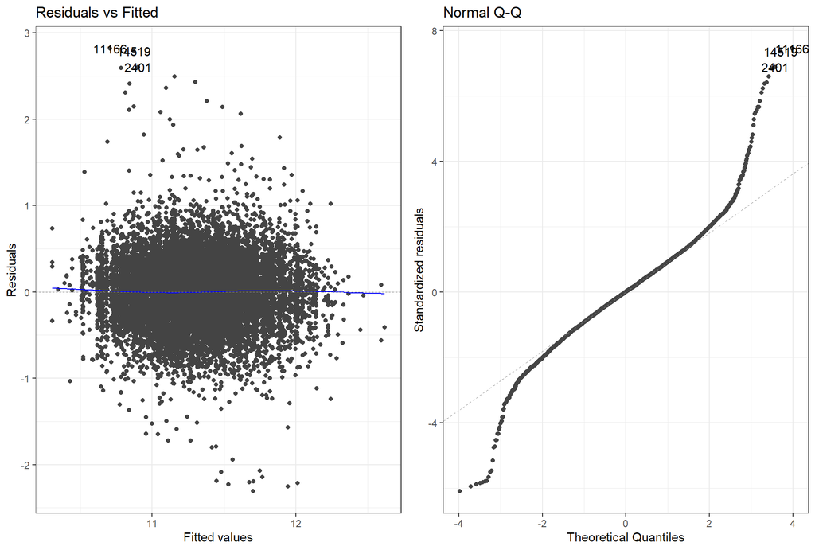

```r
library(ggfortify) #Package for residual analysis

#Plotting graphs for residual analysis
autoplot(model6, which = 1:2) +
  #Using black and white theme
  theme_bw()
```

> By performing Residual Analysis, we observe that there is no significant pattern in the Residuals vs Fitted values plot. We can conclude that there is no strong evidence of non-linear relationship between X & Y or non-constant variance. There seems to be no significant pattern in the data that is currently unaccounted for.

> The Q-Q plot has most of the values on the straight line between -2 and +2. Hence, we can conclude that the residuals follow a Normal Distribution.

> We conclude that the log of annual salary can be best explained by the model with field_exp_grouped, race_cleaned, gender, edu_level_grouped, industry_grouped and state_grouped. We are able to explain 44% of the variability in log of annual salaries.